# Understanding the Gendered S.O.E. Experience

# Understanding the Gendered S.O.E. Experience

**NOTE: Content featured may be difficult for some audiences to consume, including discussions of sexual assault and violence. Viewer discretion is advised.**

The Special Operations Executive, or the S.O.E., was a civilian branch of the British Army during the Second World War tasked with espionage behind enemy lines in both the Asian and European spheres of war. These agents ranged from housewives to hardened soldiers, whose varied identities create a unique area of analysis for gender history, and how masculinity and femininity separately affected these agents in recruitment, deployment, capture, execution, and survival. However, between limited access to agents files, and the secretive nature of much of their word, these agents have evaded historical and intersectional analysis.

This project, Understanding the Gendered S.O.E. Experience, divided into life, death, and legacy, is a first attempt at understanding the impact of gender on these agent’s experiences in the field using digital methods, turning python programming into a powerful tool in revealing the hidden histories behind agents lives.

# Alive Agents

To first understand the impact of gender on agents who survived the war is to first choose a set of agents to analyze. Seeing as there were thousands of agents deployed, this can be quite the challenge.

Let's begin with female agents.

Female agents were far less likely to be deployed than male, with only 45 deployed, though this number is up to the researcher's discretion of whom they choose to consider an agent. My personal criteria for a female S.O.E. agent was that they had to have some form of personnel record with the British National Archives. For example, there were many women who aided the resistance, but only those actually recruited and deployed would have actual personnel records.

Of these, 31 survived the war, or in the case of Madeline Lavigne and Muriel Byck, did not die in action. (Having passed from natural causes, I've chosen to include these women in the alive agents section, as the dead agent analyze focuses solely on agents killed from their line of work.)

From here, it was far more difficult to pick male agents. After all, there is no way to analyze **all** male agents within the given scope and timeframe of this project, but just choosing a random handful also does not tell the whole picture.

As such, I've chosen 31 male agents who were deployed at the **SAME TIME** as female agents. For some male agents, this means they were deployed together with female agents and worked in the field with them, while for others, they were deployed on the same day, or within a close time frame. This way, we can understand gendered experiences by studying agents who, if deployed at the same time with the same conditions, should have similar experiences. The gendered differences of those experiences, then, can be analyzed.

There are, of course, certain issues with this. In some cases, agents deployed alongside female agents were killed, meaning they could not be used for studying the effects of gender on survival. For others, they could not be tracked, such as Henri Bouchard, deployed with Peggy Knight, who was supposedly captured and released by the Germans, however there was no trail or evidence of this, save for a document on Ancestry, in which a Henri Bouchard was included in a list of freed persecutees, who was leaving a factory. As such, there has been my authorial discretion in using certain agents over others.

What I hope that by having 31 female agents, and 31 male agents deployed at the same time as them, I can show a fraction of how gender impacted spies in the field through direct correlations. This project is by no means the WHOLE picture, nor do I claim that my correlations count for ALL agents. As well, it is important to know that the overage percentages are heavily skewed by the equal split between male and female agents, for if this included all agents, the ratio would see far more men holding far more sway over female agents percentages. This is something I will discuss within the graphs as needed.

# CSV Breakdown

To then begin with the code, here is the CSV I created that contained what I believed to be relevant information to the agents in the field:

Their name, and for women, typically their maiden name. This is due to the fact that many married after the war, meaning the names included on documents used would be their maiden name.

Their country and exact location of FIRST deployment. This specification is due to the fact that some agents were deployed multiple locations across both Europe and Asia. In other cases, agents were previously deployed with other organizations, or outside of S.O.E. contracts, such as Krystyna Skarbek, better known as Christine Granville, who previously worked in Poland before becoming an official S.O.E. agent and being deployed in France.

For these reasons, I've also included deployed mutliple times and for multiple locations columns, as some agents were deployed into a single country multiple times, or to multiple countries.

Location of Origin and Date of Birth is to understand how Agent's home countries, and ages, impacted their work in the field, alongside gender.

Year of Deployment, while fairly straightforward, also contains nuance. Certain agents worked for the French resistance before being recruited by the S.O.E. Year of deployment, then, is when agents are redeployed into a country after receiving S.O.E. training, either in the UK, or within their country of deployment.

Injury and Capture is to see if agents suffered in the field outside of death. Injury counts as the reason for agents removal from the field, whereas agents could be captured and escape, returning to their position or the UK.

Total Months in the Field, Excluding Capture, is how long agents spent into the field, whether it was just one trip, or tallied if multiple.

Job Title, finally, is the given job title agents were given. Terminology varies for some, such as Wireless Operators, Wireless Transmitters, Radio Operators, etc, so I have chosen the most widely used term.

To give a brief overview: wireless operators manned wireless radios to recieve and send messages; couriers ran messages between groups; reconnaisence gathered information; liason officers worked with resistance groups; organisers organised and ran circuits; weapons and sabotage instructors, though similar, seperately taught resistance groups how to use weapons and sabotage techniques respectively; guerilla operator worked with guerilla groups in Asia; Second in Command is the secondary leader beside the organiser; and some agents became a mix of these roles, often due to the killing of an agent in their network, requiring them to take on new roles.

As well, it is worth noting the unique sequence of agents: the female-male back and forth of each row signifies that each pair of agents were deployed at or around the same time, starting with Sonya Butt and George Millar, then Virginia Hall and Benjamin H. Cowburn, so on, and so forth.

With all that said, lets get into these agents!

```python
import pandas
import folium
import geopy

from geopy.geocoders import Nominatim

geolocator = Nominatim(user_agent="War_Alive", timeout=2)

Alive = pandas.read_csv('SUSANCSVALIVE21.csv', delimiter=",")
pandas.options.display.max_rows = 999

Alive.drop('Deployment Pairing', axis=1)
```

|  | Name | Country of Deployment | First Area of Deployment | Deployed Multiple Times | Deployed to multiple Countries | Location of Origin | Gender | Date of Birth | Year of Deployment | Injury/Other | Capture | Total Months in the Field (Excluding Capture) | Job Title |
| --- | --- | --- | --- | --- | --- | --- | --- | --- | --- | --- | --- | --- | --- |
| 0 | Sonya Butt | France | La Cropte, France | No | No | England | Female | 1924 | 1944 | No | No | 5 | Courier |
| 1 | George Millar | France | Chaignay, 21120, France | No | No | Scotland | Male | 1910 | 1944 | No | No | 3 | Organiser |
| 2 | Virginia Hall | France | Vichy, France | No | No | America | Female | 1906 | 1941 | No | No | 15 | Organiser |
| 3 | Benjamin H Cowburn | France | Lothiers, France | Yes | No | England | Male | 1909 | 1941 | No | No | 16 | Organiser |
| 4 | Yvonne Baseden | France | Herré, France | No | No | France | Female | 1922 | 1944 | No | Yes | 3 | Wireless Operator |
| 5 | Adolf Feingold | France | Marseille, France | No | No | Poland | Male | 1920 | 1944 | No | No | 1 | Assassin |
| 6 | Yvonne Fontaine | France | 29620 Guimaëc, France | No | No | France | Female | 1913 | 1944 | No | No | 7 | Courier |
| 7 | Percy Mayer | France | Loubressac, France | No | No | Mauritius | Male | 1903 | 1944 | No | No | 6 | Liason Officer |
| 8 | Yvonne Cormeau | France | St Antoine du Queyret, Gironde, France | No | No | China | Female | 1909 | 1943 | Yes | No | 13 | Wireless Operator |
| 9 | André Bouchardon | France | Mayenne, France | No | No | France | Male | 1922 | 1943 | Yes | No | 7 | Wireless Operator |
| 10 | Alix d'Unienville | France | Loir et Cher, France | No | No | Mauritius | Female | 1918 | 1944 | No | Yes | 3 | Wireless Operator |
| 11 | Charles Corbin | France | Angoulème, France | No | No | France | Male | 1894 | 1944 | No | No | 5 | Organiser |
| 12 | Anne-Marie Walters | France | Landes, France | No | No | Switzerland | Female | 1923 | 1944 | No | No | 7 | Courier |
| 13 | Claude Georges Arnault | France | Landes, France | No | No | Vietnam | Male | 1925 | 1944 | No | No | 7 | Sabotage Instructor |
| 14 | Blanche Charlet | France | Cap-d’Ail, France | No | No | England | Female | 1898 | 1942 | No | Yes | 1 | Courier |
| 15 | Pierre Boutoule | France | La Tour du Pin, France | Yes | No | France | Male | 1918 | 1942 | No | Yes | 15 | Sabotage Instructor |
| 16 | Danielle Redde | Laos | Thakhek, Laos | No | No | France | Female | 1911 | 1944 | No | No | 3 | Wireless Operator |
| 17 | Jean Deuve | Laos | Paksane, Laos | No | No | France | Male | 1918 | 1945 | No | No | 7 | Guerilla Commander |
| 18 | Eileen Nearne | France | Faucon, France | No | No | England | Female | 1921 | 1944 | No | Yes | 5 | Wireless Operator |
| 19 | William Jean Savy | France | Faucon, France | Yes | No | France | Male | 1906 | 1944 | No | No | 1 | Organiser |
| 20 | Elaine Madden | Belgium | Beauraing, Belgium | Yes | Yes | Belgium | Female | 1923 | 1944 | No | No | 7 | Courier |
| 21 | André Wendelen | Belgium | Beauraing, Belgium | Yes | No | Belgium | Male | 1915 | 1944 | No | No | 15 | Organiser |
| 22 | Elizabeth Devereaux Rochester | France | Bletterans, France | No | No | America | Female | 1917 | 1943 | No | Yes | 5 | Courier |
| 23 | Owen Denis Johnson | France | Bletterans, France | No | No | America | Male | 1908 | 1943 | No | No | 11 | Wireless Operator |
| 24 | Francine Agazarian | France | Vivonne, Vienne, France | No | No | France | Female | 1913 | 1943 | No | No | 3 | Courier |
| 25 | Francis Cammaerts | France | Compiègne, France | Yes | No | France | Male | 1916 | 1943 | No | Yes | 15 | Organiser |
| 26 | Giliana Balmaceda | France | Vichy, France | No | No | Chile | Female | 1910 | 1941 | No | No | 1 | Reconnaissance |
| 27 | Roger Cotton-Burnett | France | Kergicquel, 56500 Évellys, France | No | No | France | Male | 1903 | 1941 | No | Yes | 12 | Second in Command |
| 28 | Ginette Jullian | France | Saint-Viâtre, France | No | No | France | Female | 1917 | 1944 | No | No | 3 | Wireless Operator |
| 29 | Gustave Duclos | France | Aube, France | No | No | France | Male | 1916 | 1944 | No | No | 2 | Sabotage Instructor, Organiser |
| 30 | Jaqueline Nearne | France | Haute Loire, France | No | No | England | Female | 1916 | 1943 | No | No | 15 | Courier |
| 31 | Maurice Southgate | France | Haute Loire, France | Yes | No | England | Male | 1913 | 1943 | No | Yes | 12 | Organiser |
| 32 | Julienne Aisner | France | Le Port, 37510 Villandry, France | No | No | France | Female | 1899 | 1943 | No | No | 11 | Courier |
| 33 | Gaston Collin | France | Bazemont, France | Yes | No | England | Male | 1918 | 1943 | No | No | 11 | Wireless Operator |
| 34 | Krystyna Skarbek | France | Vassieux en Vercors, France | No | No | Poland | Female | 1908 | 1944 | No | No | 3 | Courier |
| 35 | Marcel Veilleux | France | Izernore, France | No | No | Canada | Male | 1921 | 1944 | No | No | 2 | Wireless Operator |
| 36 | Lise De Baissac | France | Bois Renard, 41210 Saint-Viâtre, France | Yes | No | Mauritius | Female | 1905 | 1942 | No | No | 14 | Courier, Liaison Officer |
| 37 | Sydney Hudson | France | Plauzat, France | Yes | Yes | England | Male | 1910 | 1942 | No | Yes | 18 | Organiser |
| 38 | Maddalena Cerasuolo | Italy | Naples, Italy | No | No | Italy | Female | 1920 | 1943 | No | No | 4 | Reconnaissance |
| 39 | Massimo Salvadori | Italy | Sicily, Italy | Yes | Yes | England | Male | 1908 | 1943 | No | No | 15 | Liason Officer |
| 40 | Madeline Lavigne | France | Chissey-lès-Mâcon, France | No | No | France | Female | 1912 | 1944 | Yes | No | 4 | Wireless Operator |
| 41 | Lionel Guy d'Artois | France | Chissey-lès-Mâcon, France | No | No | Canada | Male | 1917 | 1944 | No | No | 6 | Organiser |
| 42 | Marie-Thérèse Le Chêne | France | Port Miou, France | No | No | France | Female | 1890 | 1942 | No | No | 9 | Courier |
| 43 | George Reginald Starr | France | Port Miou, France | No | No | England | Male | 1904 | 1942 | No | No | 22 | Organiser |
| 44 | Mary Katherine Herbert | France | Port Miou, France | No | No | Ireland | Female | 1903 | 1942 | Yes | Yes | 14 | Courier |
| 45 | Roger Landes | France | Bois Renard, 41210 Saint-Viâtre, France | Yes | Yes | France | Male | 1916 | 1942 | No | No | 22 | Wireless Operator, Organiser |
| 46 | Muriel Byck | France | Issoudun, France | No | No | England | Female | 1918 | 1944 | Yes | No | 1 | Wireless Operator |
| 47 | Peter Lake | France | Siorac-en-Périgord, France | No | No | England | Male | 1915 | 1944 | No | No | 5 | Weapons Instructor |
| 48 | Nancy Wake | France | Les Chenus, 03350 Le Vilhain, France | No | No | New Zealand | Female | 1912 | 1944 | No | No | 5 | Liason Officer |
| 49 | John Hind Farmer | France | Les Chenus, 03350 Le Vilhain, France | No | No | England | Male | 1917 | 1944 | No | No | 2 | Organiser |
| 50 | Odette Hallowes | France | Port Miou, France | No | No | France | Female | 1912 | 1942 | No | Yes | 5 | Courier |
| 51 | Arthur Staggs | France | Gondreville, France | No | No | England | Male | 1912 | 1942 | No | Yes | 13 | Wireless Operator |
| 52 | Odette Wilen | France | Les Souches, 36210 Chabris, France | No | No | England | Female | 1919 | 1944 | No | No | 4 | Wireless Operator, Courier |
| 53 | Raphael Charles Beauclerk | France | Siorac-en-Périgord, France | No | No | England | Male | 1917 | 1944 | No | No | 5 | Wireless Operator |
| 54 | Paddy O'Sullivan | France | Figeac, France | No | No | Ireland | Female | 1918 | 1944 | No | No | 7 | Wireless Operator |
| 55 | Kenneth Yves Marcel MACKENZIE | France | Foix, France | No | No | Scotland | Male | 1916 | 1944 | No | No | 6 | Wireless Operator |
| 56 | Pearl Withingerton Cornioley | France | Lothiers, France | No | No | France | Female | 1914 | 1943 | No | No | 12 | Courier, Organiser |
| 57 | Henri Coleman | France | Lyons, France | No | No | France | Male | 1908 | 1943 | No | No | 12 | Assistant Organiser |
| 58 | Peggy Knight | France | Poinçon-les-Larrey, France | No | No | France | Female | 1920 | 1944 | No | No | 6 | Courier |
| 59 | Antoine Sereni | France | Moissieu sur Dolon, France | No | No | France | Male | 1913 | 1944 | No | No | 4 | Wireless Operator |
| 60 | Phylis Latour | France | Mont du Saule, Hardanges, France | No | No | South Africa | Female | 1921 | 1944 | No | No | 3 | Wireless Operator |
| 61 | Edwin Poitras | France | Montbarrey, France | No | No | America | Male | 1922 | 1944 | No | No | 4 | Wireless Operator |

Now, knowing that agents come in pairs based on deployment, how close was that deployment?

```python
FranceHolder = 0

ItalyHolder = 0

BelgiumHolder = 0

for index, row in Alive.iterrows():

    if('Female' in row['Gender']):
        if('France' in row['Country of Deployment']):
            FranceHolder += 1

        elif('Italy' in row['Country of Deployment']):
            ItalyHolder+= 1

        elif('Belgium' in row['Country of Deployment']):
            BelgiumHolder+= 1
        else:
            print("There was 1 female agent(s) deployed in", row['Country of Deployment'])


print("There were", FranceHolder, " female agent(s) deployed in France")

print("There was", ItalyHolder, " female agent(s) deployed in Italy")

print("There was", BelgiumHolder, " female agent(s) deployed in Belgium")

Together = pandas.read_csv('TimingCSV3.csv', delimiter=",")
pandas.options.display.max_rows = 999

Together
```

```
There was 1 female agent(s) deployed in Laos
There were 28  female agent(s) deployed in France
There was 1  female agent(s) deployed in Italy
There was 1  female agent(s) deployed in Belgium
```

|  | Female Agent | Male Agent | Deployment Timing | Location |
| --- | --- | --- | --- | --- |
| 0 | Alix d'Unienville | Charles Corbin | 9 Days Apart | France |
| 1 | Anne-Marie Walters | Claude Georges Arnault | Same Day, Same Mission | France |
| 2 | Blanche Charlet | Pierre Boutoule | 1 Day Apart | France |
| 3 | Eileen Nearne | William Jean Savy | Same Day, Same Mission | France |
| 4 | Elaine Madden | André Wendelen | Same Day, Same Mission | Belgium |
| 5 | Elizabeth Devereaux Rochester | Owen Denis Johnson | Same Day, Same Mission | France |
| 6 | Francine Agazarian | Francis Cammaerts | 6 Days Apart | France |
| 7 | Giliana Balmaceda | Roger Cotton-Burnett | 10 Days Apart | France |
| 8 | Ginette Jullian | Gustave Duclos | 5 Days Apart | France |
| 9 | Jaqueline Nearne | Maurice Southgate | Same Day, Same Mission | France |
| 10 | Julienne Aisner | Gaston Collin | 29 Days Apart | France |
| 11 | Krystyna Skarbek | Marcel Veilleux | Same Day, Different Mission | France |
| 12 | Lise De Baissac | Sydney Hudson | Same Day, Different Mission | France |
| 13 | Maddalena Cerasuolo | Massimo Salvadori | 1 Month* | Italy |
| 14 | Marie-Thérèse Le Chêne | George Reginald Starr | Same Day, Same Mission | France |
| 15 | Mary Katherine Herbert | Roger Landes | 3 Days Apart | France |
| 16 | Nancy Wake | John Hind Farmer | Same Day, Same Mission | France |
| 17 | Odette Hallowes | Arthur Staggs | 12 Days Apart | France |
| 18 | Odette Wilen | Raphael Charles Beauclerk | 2 Days Apart | France |
| 19 | Paddy O'Sullivan | Kenneth Yves Marcel MACKENZIE | 2 Days Apart | France |
| 20 | Pearl Withingerton Cornioley | Henri Coleman | 7 Days Apart | France |
| 21 | Peggy Knight | Antoine Sereni | 6 Days Apart | France |
| 22 | Phylis Latour | Edwin Poitras | Same Day, Different Mission | France |
| 23 | Sonya Butt | George Millar | 4 Days Apart | France |
| 24 | Danielle Redde | Jean Deuve | 8 Months Apart* | Laos |
| 25 | Yvonne Baseden | Adolf Feingold | 8 Day Apart | France |
| 26 | Yvonne Cormeau | André Bouchardon | 2 Days Apart | France |
| 27 | Virginia Hall | Benjamin H Cowburn | 14 Days Apart | France |
| 28 | Muriel Byck | Peter Lake | Same Day, Different Mission | France |
| 29 | Madeline Lavigne | Lionel Guy d'Artois | Same Day, Same Mission | France |
| 30 | Yvonne Fontaine | Percy Mayer | 19 Days Apart* | France |

Here, there are a couple important things to note.

For location, 28 female agents were deployed in France, with 1 agent being deployed in Belgium, Laos, and Italy respectively. So far in my research, these are all the female agents deployed that are publically available. Emphasis must be put on the word agent for this distinction, as many women aided the S.O.E., but few were actively recruited, joined the organization, and sent in the field. It ought to be noted that S.O.E. agents worked across numerous countries, but the limitations of the deployment locations of female agents has in turn limited the amount of areas included in my own analysis.

What about those women, then, deployed outside of France?

Danielle Redde wasis the only female agents in this dataset outside of Europe, being parachuted into Laos, a unique exception to the male-dominated Asian sphere of S.O.E. work. Similarly, Madelena Cerasuolo and Elaine Madden were unique exceptions to those deloyed in Europe but outside of France in Italy and Belgium respectively, which both featured smaller S.O.E. campaigns, and needed native women like Madden and Cerasuolo to support their cause. _

For Deployment Timing, Same Day, Same Mission means agents were deployed in the exact same locations at the same time, while Same Day, Different Missions means agents were deployed the same day, but were deployed in different locations.

There are a few asterisks for Deployment Timing, some of which are due to location. While the F Section (France) has been heavily research, other areas have not, so finding agents deployed at the same time can be quite difficult, as seen in the 8 month gap between Redde and Deuve.

Well, what about shared locations for deployment?

```python
Alive[Alive.duplicated(keep=False, subset='First Area of Deployment')].sort_values(by="First Area of Deployment", ascending=True).drop(columns=['Job Title', 'Location of Origin','Country of Deployment','Deployed Multiple Times','Deployed to multiple Countries','Injury/Other','Date of Birth','Capture'])
```

|  | Name | Deployment Pairing | First Area of Deployment | Gender | Year of Deployment | Total Months in the Field (Excluding Capture) |
| --- | --- | --- | --- | --- | --- | --- |
| 20 | Elaine Madden | F | Beauraing, Belgium | Female | 1944 | 7 |
| 21 | André Wendelen | F | Beauraing, Belgium | Male | 1944 | 15 |
| 22 | Elizabeth Devereaux Rochester | G | Bletterans, France | Female | 1943 | 5 |
| 23 | Owen Denis Johnson | G | Bletterans, France | Male | 1943 | 11 |
| 45 | Roger Landes | R | Bois Renard, 41210 Saint-Viâtre, France | Male | 1942 | 22 |
| 36 | Lise De Baissac | N | Bois Renard, 41210 Saint-Viâtre, France | Female | 1942 | 14 |
| 40 | Madeline Lavigne | P | Chissey-lès-Mâcon, France | Female | 1944 | 4 |
| 41 | Lionel Guy d'Artois | P | Chissey-lès-Mâcon, France | Male | 1944 | 6 |
| 18 | Eileen Nearne | E | Faucon, France | Female | 1944 | 5 |
| 19 | William Jean Savy | E | Faucon, France | Male | 1944 | 1 |
| 31 | Maurice Southgate | K | Haute Loire, France | Male | 1943 | 12 |
| 30 | Jaqueline Nearne | K | Haute Loire, France | Female | 1943 | 15 |
| 12 | Anne-Marie Walters | B | Landes, France | Female | 1944 | 7 |
| 13 | Claude Georges Arnault | B | Landes, France | Male | 1944 | 7 |
| 49 | John Hind Farmer | T | Les Chenus, 03350 Le Vilhain, France | Male | 1944 | 2 |
| 48 | Nancy Wake | T | Les Chenus, 03350 Le Vilhain, France | Female | 1944 | 5 |
| 56 | Pearl Withingerton Cornioley | X | Lothiers, France | Female | 1943 | 12 |
| 3 | Benjamin H Cowburn | @ | Lothiers, France | Male | 1941 | 16 |
| 43 | George Reginald Starr | Q | Port Miou, France | Male | 1942 | 22 |
| 44 | Mary Katherine Herbert | R | Port Miou, France | Female | 1942 | 14 |
| 50 | Odette Hallowes | U | Port Miou, France | Female | 1942 | 5 |
| 42 | Marie-Thérèse Le Chêne | Q | Port Miou, France | Female | 1942 | 9 |
| 53 | Raphael Charles Beauclerk | V | Siorac-en-Périgord, France | Male | 1944 | 5 |
| 47 | Peter Lake | S | Siorac-en-Périgord, France | Male | 1944 | 5 |
| 26 | Giliana Balmaceda | I | Vichy, France | Female | 1941 | 1 |
| 2 | Virginia Hall | @ | Vichy, France | Female | 1941 | 15 |

Okay, so what's with the random letters?

For those with a matching location, but different letters, however, it shows that some agents worked in the same locations, though were not deployed there at the same time. This is the case for Cornioley and Cowburn, who were both deployed to Lothiers, but Cornionley in 1943, and Cowburn in 1941, with Cowburn lasting 16 months in the field, and Cornioley lasting 12.

# Alive Agents Locations

So, with an overall understanding of the agents we're working with, lets map their locations! Red parachutes represent female agents, with green representing male. **PLEASE NOTE: YOU WILL NEED TO REALLY ZOOM IN TO PROPERLY SEE CERTAIN CLUSTERS OF AGENTS DEPLOYED TO THE SAME LOCATION**

```python
Alive_map = folium.Map(location=[46.2276, 2.2137], zoom_start=3)
import time

increase = 0

icon_url = 'https://cdn-icons-png.flaticon.com/512/4533/4533299.png'
icon_url2 = 'https://cdn-icons-png.flaticon.com/512/238/238569.png'

for index, row in Alive.iterrows():

    if('Female' in row['Gender']):
        time.sleep(.7)

        location = geolocator.geocode(row['First Area of Deployment'], language='en')

        year = row['Year of Deployment']
        name = row['Name']
        Descript = "Agent:", name, "Date of Deployment:", year


        increase +=0.00001

        Final_Lat = (location.latitude + increase)

        Final_Log = (location.longitude + increase)


        icon = folium.features.CustomIcon(icon_url,icon_size=(28, 30))

        folium.Marker(location=[Final_Lat, Final_Log],popup = Descript, icon=icon).add_to(Alive_map)
    else:
        time.sleep(.51)

        location = geolocator.geocode(row['First Area of Deployment'], language='en')

        year = row['Year of Deployment']
        name = row['Name']
        Descript = "Agent:", name, "Date of Deployment:", year

        increase +=0.00001

        Final_Lat = (location.latitude + increase)

        Final_Log = (location.longitude + increase)



        icon = folium.features.CustomIcon(icon_url2,icon_size=(28, 30))

        folium.Marker(location=[Final_Lat, Final_Log],popup = Descript, icon=icon).add_to(Alive_map)

Alive_map
```

Make this Notebook Trusted to load map: File -> Trust Notebook

[interactive chart not shown]

## Overall Agent Understanding

So, before we break down impacts on gender, what overall understanding should we have?

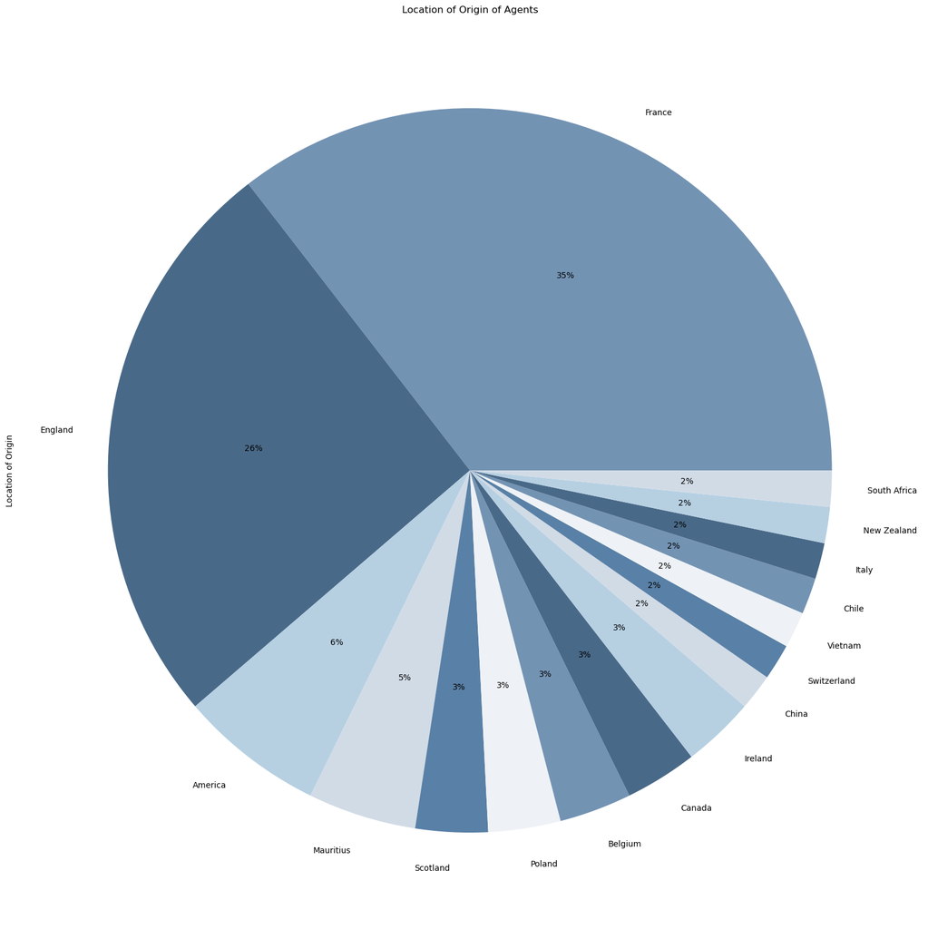

```python
colorsALL = ['#7393B3', '#496988','#B6D0E2','#D1DBE6','#5980A6','#EEF2F6']



Alive['Location of Origin'].value_counts().plot(kind='pie',figsize=(20,20),autopct='%1.0f%%',title='Location of Origin of Agents', colors=colorsALL)
```

26% of Agents come from England, which makes sense considering S.O.E. is an English operation, and is close to France, meaning many likely already had experience speaking French, or with French culture.

Following France and England, most agents came from parts of the British Empire, with only 13% of agents coming from outside of Europe and North America. Of this dataset, Giliana Balmeceda is the only agent to come from South America, and Nancy Wake being the only agent from Oceania.

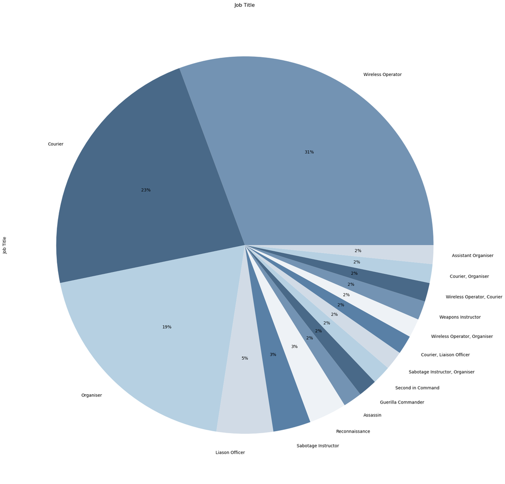

```python
Alive['Job Title'].value_counts().plot(kind='pie',figsize=(20,20),autopct='%1.0f%%',title='Job Title', colors=colorsALL)
```

Here, the most common jobs for agents were Wireless Operators and Couriers, which might be swayed due to the fact that female agents were expected to be ONLY couriers or wireless operators, as it was believed this was safer work than espionage in the field. Considering half of the dataset is made up of women, this would sway the data in favour of Couriers and Wireless Operators.

## Overall Deployment by Time

Another important aspect in understanding the S.O.E. experience is the time they spent in the field, and when they were deployed. So, what was the spread of agents over the years of the war?

```
4  agents were deployed in 1941,  2  were women, and  2  were men.
10  agents were deployed in 1942,  5  were women, and  5  were men.
14  agents were deployed in 1943,  7  were women, and  7  were men.
33  agents were deployed in 1944,  17  were women, and  16  were men.
1  agents were deployed in 1945,  0  were women, and  1  were men.
```

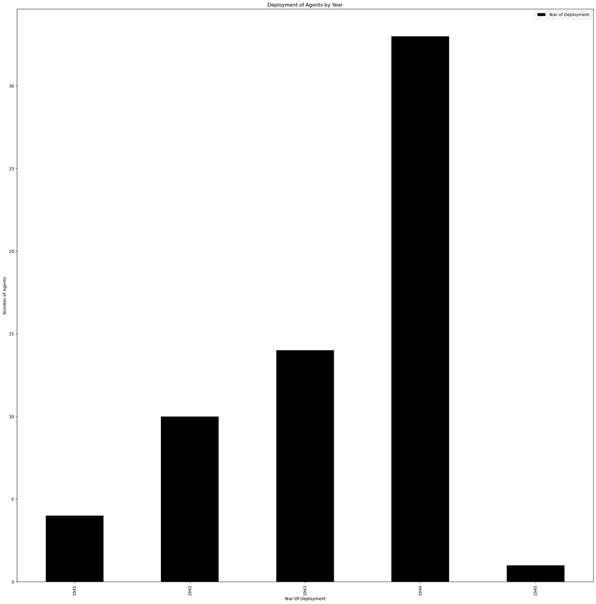

```python
counter41 = 0

counter42 = 0

counter43 = 0

counter44 = 0

counter45 = 0

femcounter41 = 0

femcounter42 = 0

femcounter43 = 0

femcounter44 = 0

femcounter45 = 0

for index, row in Alive.iterrows():

    if(row['Year of Deployment'] == 1941):
        counter41 += 1

        if('Female' in row['Gender']):
            femcounter41 += 1

    elif(row['Year of Deployment'] == 1942):
        counter42 += 1

        if('Female' in row['Gender']):
            femcounter42 += 1

    elif(row['Year of Deployment'] == 1943):
        counter43 += 1

        if('Female' in row['Gender']):
            femcounter43 += 1

    elif(row['Year of Deployment'] == 1944):
        counter44 += 1

        if('Female' in row['Gender']):
            femcounter44 += 1

    else:
        counter45 += 1
        if('Female' in row['Gender']):
            femcounter45 += 1

print(counter41, " agents were deployed in 1941, ", femcounter41, " were women, and ", (counter41-femcounter41), " were men.")

print(counter42, " agents were deployed in 1942, ", femcounter42, " were women, and ", (counter42-femcounter42), " were men.")

print(counter43, " agents were deployed in 1943, " , femcounter43, " were women, and ", (counter43-femcounter43), " were men.")

print(counter44, " agents were deployed in 1944, ", femcounter44, " were women, and ", (counter44-femcounter44), " were men.")

print(counter45, " agents were deployed in 1945, ", femcounter45, " were women, and ", (counter45-femcounter45), " were men.")

Alive['Year of Deployment'].value_counts().sort_index().plot(kind='bar',figsize=(25,25),title='Deployment of Agents by Year', color='black', linewidth=3,legend=True,ylabel='Number of Agents',xlabel='Year Of Deployment')
```

(Note: The slight discrepancies in the number of male and female agents deployed between 1944 and 1945, as mentioned above is once against due to the two agents deployed in Laos, whose gap was quite large, due to lack of other files available)

So, what does this tell us? Well, most surviving agents were deployed in 1944. There is a steady increase from 1941 to 1944, before a sheer drop into 1945. This spike in 1944 can be linked to a few different factors, the first being that there was a spike of agent capture and deaths in 1944, due to the growing anxeities of the Nazi regime as their forces waned. The second is once again due to the sway of the amount of female agents of this dataset, as the men included were deployed at the same time as them, meaning this dataset reflects female deployment far more than male.

Women, while being deployed since the beginning of the war, occupied a unique space as S.O.E. agents. On one hand, they were incredibly valuable in the world of espionage, and in going unnoticed, but on the other, gender expectations at the same saw extra protections for women, and a lot of detterance of them entering the field. We can see this deterance lessen as the war goes on, with a shocking increase of 2 to 5 to 7 to 17 women deployed by 1944, proving perhaps the S.O.E.'s desperation for agents abroad, or perhaps that, women were becoming viewed as more capable agents, and recruited and deployed more.

# PER GENDER

Now, with an overall understanding of agents, lets break down this information by gender to understand how women and men differed in the field. To begin, lets seperate men and women into two different datasets to then be able to draw from.

```python
colors = ['#358f80', '#56ab91', '#78c6a3','#afe9c4', '#aed1ba']

Female = []
Female_Name = []
Female_Age = []
Female_Age_Range = []
Female_Location = []
Female_Birth_Location = []
Female_Amount_Deployed = []
Female_Location_Deployed = []
Female_Injury = []
Female_Capture = []
Female_Months = []
Female_Job_Title = []
Female_Exact_Deploy = []
Female_Year_Deploy = []



Female_Age_Average = 0
Female_Year_Average = 0
Female_Month_Average = 0

FemalePAPAPA = []

x = 0
l = 0

for index, row in Alive.iterrows():

     if('Female' in row['Gender']):

        Female.append(row['Gender'])
        Female_Birth_Location.append(row['Location of Origin'])
        Female_Name.append(row['Name'])
        Female_Location.append(row['Country of Deployment'])
        Female_Injury.append(row['Injury/Other'])
        Female_Capture.append(row['Capture'])
        Female_Months.append(row['Total Months in the Field (Excluding Capture)'])
        Female_Job_Title.append(row['Job Title'])
        Female_Amount_Deployed.append(row['Deployed Multiple Times'])
        Female_Location_Deployed.append(row['Deployed to multiple Countries'])
        Female_Exact_Deploy.append(row['First Area of Deployment'])
        Female_Year_Deploy.append(row['Year of Deployment'])

        Age_Calc=(row['Year of Deployment']-row['Date of Birth'])
        Female_Age.append(Age_Calc)

        Female_Year_Average=row['Year of Deployment'] + Female_Year_Average
        Female_Age_Average = Female_Age_Average + Age_Calc
        Female_Month_Average = row['Total Months in the Field (Excluding Capture)'] + Female_Month_Average

        x+=1

        if(Age_Calc <= 29):
            Female_Age_Range.append("20s")
        elif(Age_Calc <= 39 and Age_Calc >= 30):
            Female_Age_Range.append("30s")
        elif(Age_Calc <= 49 and Age_Calc >= 40):
            Female_Age_Range.append("40s")
        else:
            Female_Age_Range.append("50s")


        Female_dataframe = pandas.DataFrame({'Name':Female_Name,'Gender': Female,'Age':Female_Age,'Age Range': Female_Age_Range,'Location of Deployment':Female_Location,'First Area of Deployment':Female_Exact_Deploy, 'Year of Deployment':Female_Year_Deploy,'Location of Birth':Female_Birth_Location, 'Months in the Field, Excludin Capture': Female_Months, 'Injured in the Field?': Female_Injury, 'Captured in the Field?':Female_Capture, 'Job Title': Female_Job_Title, 'Deployed Multiple Times?':Female_Amount_Deployed, 'Deployed to Multiple Countries?':Female_Location_Deployed })

Female_dataframe
```

|  | Name | Gender | Age | Age Range | Location of Deployment | First Area of Deployment | Year of Deployment | Location of Birth | Months in the Field, Excludin Capture | Injured in the Field? | Captured in the Field? | Job Title | Deployed Multiple Times? | Deployed to Multiple Countries? |
| --- | --- | --- | --- | --- | --- | --- | --- | --- | --- | --- | --- | --- | --- | --- |
| 0 | Sonya Butt | Female | 20 | 20s | France | La Cropte, France | 1944 | England | 5 | No | No | Courier | No | No |
| 1 | Virginia Hall | Female | 35 | 30s | France | Vichy, France | 1941 | America | 15 | No | No | Organiser | No | No |
| 2 | Yvonne Baseden | Female | 22 | 20s | France | Herré, France | 1944 | France | 3 | No | Yes | Wireless Operator | No | No |
| 3 | Yvonne Fontaine | Female | 31 | 30s | France | 29620 Guimaëc, France | 1944 | France | 7 | No | No | Courier | No | No |
| 4 | Yvonne Cormeau | Female | 34 | 30s | France | St Antoine du Queyret, Gironde, France | 1943 | China | 13 | Yes | No | Wireless Operator | No | No |
| 5 | Alix d'Unienville | Female | 26 | 20s | France | Loir et Cher, France | 1944 | Mauritius | 3 | No | Yes | Wireless Operator | No | No |
| 6 | Anne-Marie Walters | Female | 21 | 20s | France | Landes, France | 1944 | Switzerland | 7 | No | No | Courier | No | No |
| 7 | Blanche Charlet | Female | 44 | 40s | France | Cap-d’Ail, France | 1942 | England | 1 | No | Yes | Courier | No | No |
| 8 | Danielle Redde | Female | 33 | 30s | Laos | Thakhek, Laos | 1944 | France | 3 | No | No | Wireless Operator | No | No |
| 9 | Eileen Nearne | Female | 23 | 20s | France | Faucon, France | 1944 | England | 5 | No | Yes | Wireless Operator | No | No |
| 10 | Elaine Madden | Female | 21 | 20s | Belgium | Beauraing, Belgium | 1944 | Belgium | 7 | No | No | Courier | Yes | Yes |
| 11 | Elizabeth Devereaux Rochester | Female | 26 | 20s | France | Bletterans, France | 1943 | America | 5 | No | Yes | Courier | No | No |
| 12 | Francine Agazarian | Female | 30 | 30s | France | Vivonne, Vienne, France | 1943 | France | 3 | No | No | Courier | No | No |
| 13 | Giliana Balmaceda | Female | 31 | 30s | France | Vichy, France | 1941 | Chile | 1 | No | No | Reconnaissance | No | No |
| 14 | Ginette Jullian | Female | 27 | 20s | France | Saint-Viâtre, France | 1944 | France | 3 | No | No | Wireless Operator | No | No |
| 15 | Jaqueline Nearne | Female | 27 | 20s | France | Haute Loire, France | 1943 | England | 15 | No | No | Courier | No | No |
| 16 | Julienne Aisner | Female | 44 | 40s | France | Le Port, 37510 Villandry, France | 1943 | France | 11 | No | No | Courier | No | No |
| 17 | Krystyna Skarbek | Female | 36 | 30s | France | Vassieux en Vercors, France | 1944 | Poland | 3 | No | No | Courier | No | No |
| 18 | Lise De Baissac | Female | 37 | 30s | France | Bois Renard, 41210 Saint-Viâtre, France | 1942 | Mauritius | 14 | No | No | Courier, Liaison Officer | Yes | No |
| 19 | Maddalena Cerasuolo | Female | 23 | 20s | Italy | Naples, Italy | 1943 | Italy | 4 | No | No | Reconnaissance | No | No |
| 20 | Madeline Lavigne | Female | 32 | 30s | France | Chissey-lès-Mâcon, France | 1944 | France | 4 | Yes | No | Wireless Operator | No | No |
| 21 | Marie-Thérèse Le Chêne | Female | 52 | 50s | France | Port Miou, France | 1942 | France | 9 | No | No | Courier | No | No |
| 22 | Mary Katherine Herbert | Female | 39 | 30s | France | Port Miou, France | 1942 | Ireland | 14 | Yes | Yes | Courier | No | No |
| 23 | Muriel Byck | Female | 26 | 20s | France | Issoudun, France | 1944 | England | 1 | Yes | No | Wireless Operator | No | No |
| 24 | Nancy Wake | Female | 32 | 30s | France | Les Chenus, 03350 Le Vilhain, France | 1944 | New Zealand | 5 | No | No | Liason Officer | No | No |
| 25 | Odette Hallowes | Female | 30 | 30s | France | Port Miou, France | 1942 | France | 5 | No | Yes | Courier | No | No |
| 26 | Odette Wilen | Female | 25 | 20s | France | Les Souches, 36210 Chabris, France | 1944 | England | 4 | No | No | Wireless Operator, Courier | No | No |
| 27 | Paddy O'Sullivan | Female | 26 | 20s | France | Figeac, France | 1944 | Ireland | 7 | No | No | Wireless Operator | No | No |
| 28 | Pearl Withingerton Cornioley | Female | 29 | 20s | France | Lothiers, France | 1943 | France | 12 | No | No | Courier, Organiser | No | No |
| 29 | Peggy Knight | Female | 24 | 20s | France | Poinçon-les-Larrey, France | 1944 | France | 6 | No | No | Courier | No | No |
| 30 | Phylis Latour | Female | 23 | 20s | France | Mont du Saule, Hardanges, France | 1944 | South Africa | 3 | No | No | Wireless Operator | No | No |

```python
Mcolors = ['#9a99f2','#7c7bdb','#b3beff','#ccdcff','#e6f2ff','#b9b7ed']

Male = []
Male_Name = []
Male_Age = []
Male_Age_Range = []
Male_Location = []
Male_Birth_Location = []
Male_Amount_Deployed = []
Male_Location_Deployed = []
Male_Injury = []
Male_Capture = []
Male_Months = []
Male_Job_Title = []
Male_Exact_Deploy = []
Male_Year_Deploy = []


Male_Age_Average = 0
Male_Year_Average = 0
Male_Month_Average = 0

a = 0

for index, row in Alive.iterrows():

     if('Male' in row['Gender']):

        Male.append(row['Gender'])
        Male_Birth_Location.append(row['Location of Origin'])
        Male_Name.append(row['Name'])
        Male_Location.append(row['Country of Deployment'])
        Male_Injury.append(row['Injury/Other'])
        Male_Capture.append(row['Capture'])
        Male_Months.append(row['Total Months in the Field (Excluding Capture)'])
        Male_Job_Title.append(row['Job Title'])
        Male_Amount_Deployed.append(row['Deployed Multiple Times'])
        Male_Location_Deployed.append(row['Deployed to multiple Countries'])
        Male_Exact_Deploy.append(row['First Area of Deployment'])
        Male_Year_Deploy.append(row['Year of Deployment'])



        Male_Age_Calc=(row['Year of Deployment']-row['Date of Birth'])
        Male_Age.append(Male_Age_Calc)


        Male_Year_Average=row['Year of Deployment'] + Male_Year_Average
        Male_Age_Average = Male_Age_Average + Male_Age_Calc
        Male_Month_Average = row['Total Months in the Field (Excluding Capture)'] + Male_Month_Average


        a+=1


        if(Male_Age_Calc <= 29):
            Male_Age_Range.append("20s")
        elif(Male_Age_Calc <= 39 and Male_Age_Calc >= 30):
            Male_Age_Range.append("30s")
        elif(Male_Age_Calc <= 49 and Male_Age_Calc >= 40):
            Male_Age_Range.append("40s")
        else:
            Male_Age_Range.append("50s")


        Male_dataframe = pandas.DataFrame({'Name':Male_Name,'Gender': Male,'Age':Male_Age,'Age Range': Male_Age_Range,'Location of Deployment':Male_Location,'First Area of Deployment':Male_Exact_Deploy, 'Year of Deployment':Male_Year_Deploy,'Location of Birth':Male_Birth_Location, 'Months in the Field, Excludin Capture': Male_Months, 'Injured in the Field?': Male_Injury, 'Captured in the Field?':Male_Capture, 'Job Title': Male_Job_Title, 'Deployed Multiple Times?':Male_Amount_Deployed, 'Deployed to Multiple Countries?':Male_Location_Deployed })

Male_dataframe
```

|  | Name | Gender | Age | Age Range | Location of Deployment | First Area of Deployment | Year of Deployment | Location of Birth | Months in the Field, Excludin Capture | Injured in the Field? | Captured in the Field? | Job Title | Deployed Multiple Times? | Deployed to Multiple Countries? |
| --- | --- | --- | --- | --- | --- | --- | --- | --- | --- | --- | --- | --- | --- | --- |
| 0 | George Millar | Male | 34 | 30s | France | Chaignay, 21120, France | 1944 | Scotland | 3 | No | No | Organiser | No | No |
| 1 | Benjamin H Cowburn | Male | 32 | 30s | France | Lothiers, France | 1941 | England | 16 | No | No | Organiser | Yes | No |
| 2 | Adolf Feingold | Male | 24 | 20s | France | Marseille, France | 1944 | Poland | 1 | No | No | Assassin | No | No |
| 3 | Percy Mayer | Male | 41 | 40s | France | Loubressac, France | 1944 | Mauritius | 6 | No | No | Liason Officer | No | No |
| 4 | André Bouchardon | Male | 21 | 20s | France | Mayenne, France | 1943 | France | 7 | Yes | No | Wireless Operator | No | No |
| 5 | Charles Corbin | Male | 50 | 50s | France | Angoulème, France | 1944 | France | 5 | No | No | Organiser | No | No |
| 6 | Claude Georges Arnault | Male | 19 | 20s | France | Landes, France | 1944 | Vietnam | 7 | No | No | Sabotage Instructor | No | No |
| 7 | Pierre Boutoule | Male | 24 | 20s | France | La Tour du Pin, France | 1942 | France | 15 | No | Yes | Sabotage Instructor | Yes | No |
| 8 | Jean Deuve | Male | 27 | 20s | Laos | Paksane, Laos | 1945 | France | 7 | No | No | Guerilla Commander | No | No |
| 9 | William Jean Savy | Male | 38 | 30s | France | Faucon, France | 1944 | France | 1 | No | No | Organiser | Yes | No |
| 10 | André Wendelen | Male | 29 | 20s | Belgium | Beauraing, Belgium | 1944 | Belgium | 15 | No | No | Organiser | Yes | No |
| 11 | Owen Denis Johnson | Male | 35 | 30s | France | Bletterans, France | 1943 | America | 11 | No | No | Wireless Operator | No | No |
| 12 | Francis Cammaerts | Male | 27 | 20s | France | Compiègne, France | 1943 | France | 15 | No | Yes | Organiser | Yes | No |
| 13 | Roger Cotton-Burnett | Male | 38 | 30s | France | Kergicquel, 56500 Évellys, France | 1941 | France | 12 | No | Yes | Second in Command | No | No |
| 14 | Gustave Duclos | Male | 28 | 20s | France | Aube, France | 1944 | France | 2 | No | No | Sabotage Instructor, Organiser | No | No |
| 15 | Maurice Southgate | Male | 30 | 30s | France | Haute Loire, France | 1943 | England | 12 | No | Yes | Organiser | Yes | No |
| 16 | Gaston Collin | Male | 25 | 20s | France | Bazemont, France | 1943 | England | 11 | No | No | Wireless Operator | Yes | No |
| 17 | Marcel Veilleux | Male | 23 | 20s | France | Izernore, France | 1944 | Canada | 2 | No | No | Wireless Operator | No | No |
| 18 | Sydney Hudson | Male | 32 | 30s | France | Plauzat, France | 1942 | England | 18 | No | Yes | Organiser | Yes | Yes |
| 19 | Massimo Salvadori | Male | 35 | 30s | Italy | Sicily, Italy | 1943 | England | 15 | No | No | Liason Officer | Yes | Yes |
| 20 | Lionel Guy d'Artois | Male | 27 | 20s | France | Chissey-lès-Mâcon, France | 1944 | Canada | 6 | No | No | Organiser | No | No |
| 21 | George Reginald Starr | Male | 38 | 30s | France | Port Miou, France | 1942 | England | 22 | No | No | Organiser | No | No |
| 22 | Roger Landes | Male | 26 | 20s | France | Bois Renard, 41210 Saint-Viâtre, France | 1942 | France | 22 | No | No | Wireless Operator, Organiser | Yes | Yes |
| 23 | Peter Lake | Male | 29 | 20s | France | Siorac-en-Périgord, France | 1944 | England | 5 | No | No | Weapons Instructor | No | No |
| 24 | John Hind Farmer | Male | 27 | 20s | France | Les Chenus, 03350 Le Vilhain, France | 1944 | England | 2 | No | No | Organiser | No | No |
| 25 | Arthur Staggs | Male | 30 | 30s | France | Gondreville, France | 1942 | England | 13 | No | Yes | Wireless Operator | No | No |
| 26 | Raphael Charles Beauclerk | Male | 27 | 20s | France | Siorac-en-Périgord, France | 1944 | England | 5 | No | No | Wireless Operator | No | No |
| 27 | Kenneth Yves Marcel MACKENZIE | Male | 28 | 20s | France | Foix, France | 1944 | Scotland | 6 | No | No | Wireless Operator | No | No |
| 28 | Henri Coleman | Male | 35 | 30s | France | Lyons, France | 1943 | France | 12 | No | No | Assistant Organiser | No | No |
| 29 | Antoine Sereni | Male | 31 | 30s | France | Moissieu sur Dolon, France | 1944 | France | 4 | No | No | Wireless Operator | No | No |
| 30 | Edwin Poitras | Male | 22 | 20s | France | Montbarrey, France | 1944 | America | 4 | No | No | Wireless Operator | No | No |

## Average Age, Year of Deployment, and Time in the Field

Before we begin, lets look at a case study: Marie-Therese le Chene and George Reginald Starr.

These two agents were deployed the same day, on the same airdrop. Starr was an organiser in the field, while le Chene was a courier, and neither were captured or redeployed.

Le Chene only lasted 9 months in the field, while Starr lasted a whopping 22, the longest time recorded for male S.O.E. agents, as you'll see below.

So, what conditions might explain their differences in time in the field?

Another condition could be their jobs. Le Chene was a courier, meaning that she was constantly on the move and would have had to pass more checkpoints and be seen more by Nazi officers. Starr, on the other hand, was an organiser, meaning he was hiding and leading the Maquis. Le Chene, in the public, could have raised more suspicion leading to her needing to needing to leave the field, while Starr's more secretive role could have kept him in the field longer.

In reality, what mainly impacted these agents time in the field is their circuits. Le Chene was part of a small circuit called 'Plane', run by her husband which ended quickly, while Starr was the organiser of the 'Wheelwright' circuit, a far larger and longer lasting network that kept him in the field. **1**

The point of this case study is to prove that are many possible answers to what factors effects agents in the field. It can be easy, when studying gender, to try and jump to a conclusion: that le Chene lasted less time than Starr because she was female. This is not what I want my work to be. Instead, I aim to show that gender could be one aspect affecting agents in the field, and using digital methods to prove so.

So, lets begin by seeing how gender affected the age, year of deployment, and time in the field of agents.

## Women

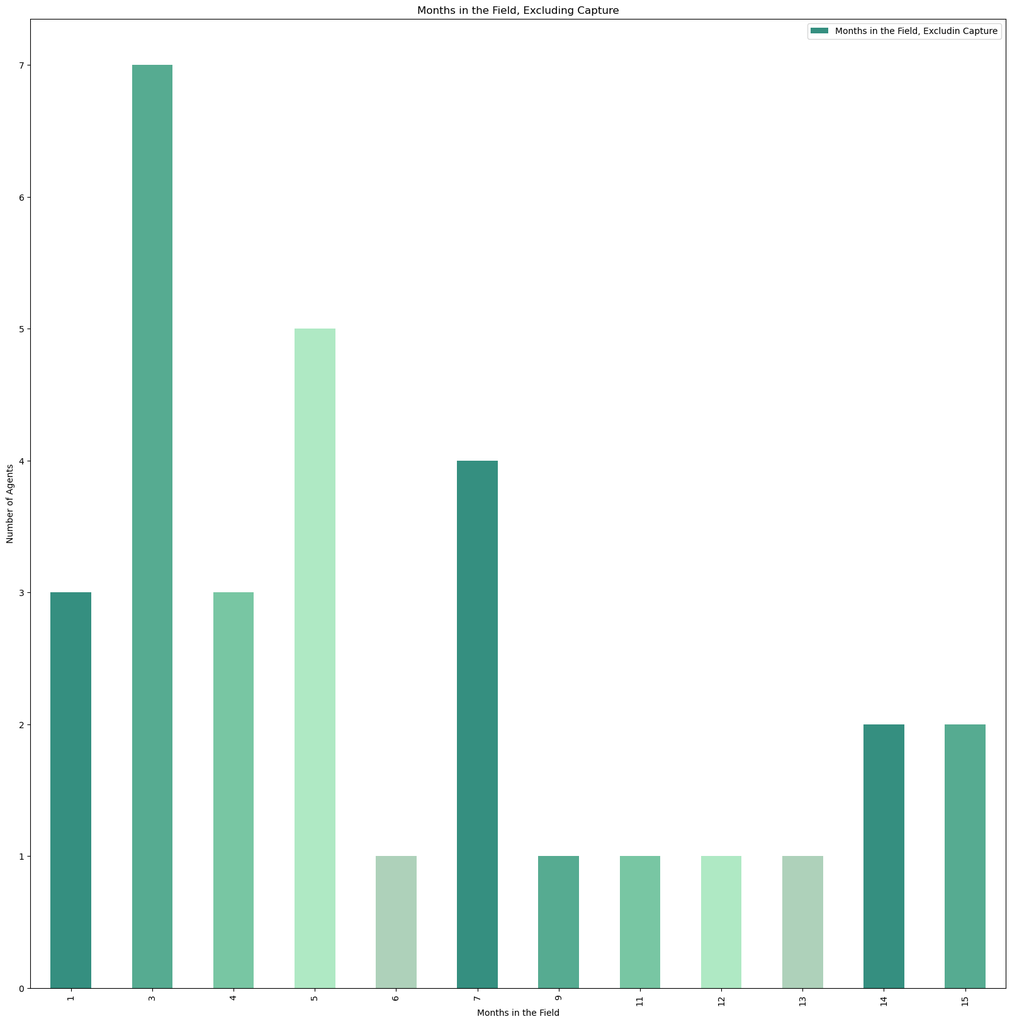

```python
Female_dataframe['Months in the Field, Excludin Capture'].value_counts().sort_index().plot(kind='bar',figsize=(20,20),title='Months in the Field, Excluding Capture', color=colors, linewidth=3,legend=True,ylabel='Number of Agents',xlabel='Months in the Field')
```

## Men

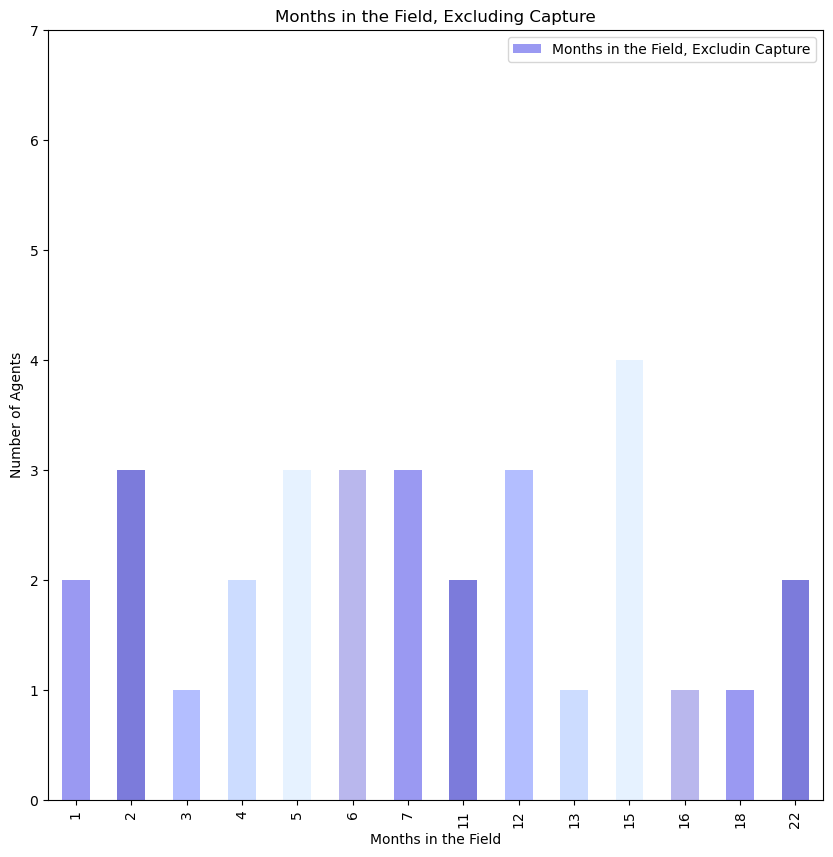

```python
Male_dataframe['Months in the Field, Excludin Capture'].value_counts().sort_index().plot(kind='bar',figsize=(10,10),title='Months in the Field, Excluding Capture', color=Mcolors, linewidth=3,legend=True,ylabel='Number of Agents',xlabel='Months in the Field',ylim=(0, 7))
```

Women were most likely to last 3 months in the field, then 5, then 7. The longest they lasted was 15 months, and the shortest 1 month. What does this tell us about gender's impact on agents work in the field? Well, to ignore gender for one moment, S.O.E. agents lived in constant danger, and were not expected to last long in the field. It was hoped, of course, but it's claimed that male wireless operators lasted on average six weeks! Any amount of time behind enemy lines is impressive, but how might gender have impacted this? The first is in that women were frequently recalled from their missions before they were captured, whether from their own exhaustion, the dismantling of their unit, or in the case of the Nearne sisters, they were not allowed to overlap missions, in case they were used against each other.

One unique instance of gendered recalling from the field is seen with Anne-Marie Walters. Her return was not because she could not do her job, or that her unit was dismantled, or because she wanted to leave. Instead, her organiser disliked her, disagreeing with the clothes she wore, considering her disobedient, and labelling her "man mad", another term for boy crazy.**2** (Notably, in Walter's book, *Moondrop to Gascony*, a narrative account of her time as an S.O.E. agent, she excludes this part in the reason behind her evacuation from France.)

Another part of the reason that women lasted in some cases 14 to 15 months is that they stood out less than male agents, as French men had either been captured or conscripted, leaving only those unfit to fight and the elderly. Women, on the other hand, were in abundance, meaning that female S.O.E. agents could likely last longer, as they were under less suspicion.

Male Agents months in the field, on the other hand, were far more spread out, from 1 month to 22, with no major clustering of a specific time in the field. Similar to women, men were also recalled from the field for different reasons, from the collapse of their circuits to their own requests to leave the field. As we'll discuss soon, however, men's higher distrubitions of time in the field comes down to one major gendered factor: their ability to be redeployed compared to women.

```python
print("MEN:")
MaleAverageAge = round(Male_Age_Average/a)
print("The Average Age of Deployment for Male SOE Agents:",MaleAverageAge)

AverageYearofDeployMale = round(Male_Year_Average/a)
print("The Average Year Male Agents were Deployed:",AverageYearofDeployMale)


AverageTimeFieldMale = round(Male_Month_Average/x)
print("The Average time Male SOE Agents spent in the field war:", AverageTimeFieldMale)

print("WOMEN:")

AverageAge = round(Female_Age_Average/x)
print("The Average Age of Deployment for Female SOE Agents:",AverageAge)

AverageYearofDeployment = round(Female_Year_Average/x)
print("The Average Year Female SOE Agents were Deployed:", AverageYearofDeployment)

AverageTimeField = round(Female_Month_Average/x)
print("The Average time Female SOE Agents spent in the field war:", AverageTimeField)
```

```
MEN:
The Average Age of Deployment for Male SOE Agents: 30
The Average Year Male Agents were Deployed: 1943
The Average time Male SOE Agents spent in the field war: 9
WOMEN:
The Average Age of Deployment for Female SOE Agents: 30
The Average Year Female SOE Agents were Deployed: 1943
The Average time Female SOE Agents spent in the field war: 6
```

Fascinatingly, of the female agents and male agents deployed with them, their average age and year of deployment are the same! For both, the average agent in the field was 30 years old, and were deployed in 1943. The average age being 30 shows not only the want for younger agents in the field, but also agents mature enough to last.

The year of deployment being 1943 once again might be swayed by the female population, as by studying female agents and the male agents deployed with them, we are excluding a wide range of male agents, many of whom were frequently deployed from 1940 onwards, meaning that, as shown above, the wide majority of agents being deployed in 1944, and the average year of deployment in 1943, shows the growth of the S.O.E. in deployment over the war years, but also how women were relied on more as the war progressed, whereas before they were limited in being sent into the field.

A gendered differences in averages, however, is evident in the time S.O.E. agents spent in the field. Women on average only spent 6, while men spent 9. As mentioned above, this likely comes down to the fact that there was more caution surrounding female deployment, which involved them being recalled or them evacuating, whereas the same stories of recall are featured less in stories of male agents deployments. As the bar chart above shows, in comparison to women, male agents were more spread out in the the months they spent in the field, whereas women clustered in the 3, 5, and 7 month slots. Some men also lasted longer in the field than women, up to 22 months, whereas women lasted up to 15 months. Here, however, is an important part in noting why these numbers might be higher: men were fare more likely to be redeployed or deployed to multiple countries.

How much more likely? Let's see:

## Men

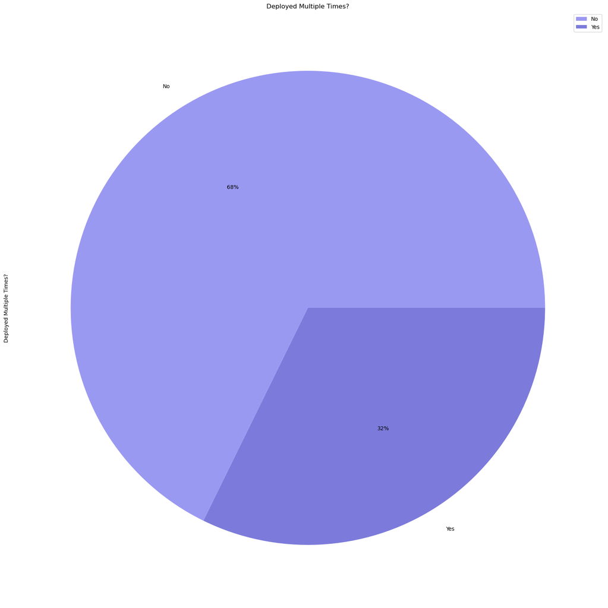

```python
Male_dataframe['Deployed Multiple Times?'].value_counts().plot(kind='pie',figsize=(20,20),title='Deployed Multiple Times?',legend=True,autopct='%1.0f%%',colors=Mcolors)
```

## Women

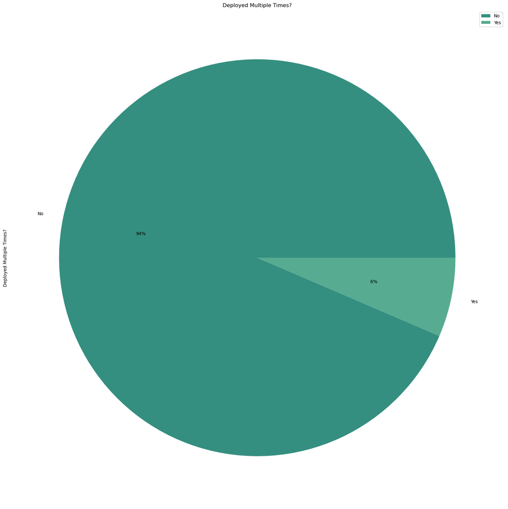

```python
Female_dataframe['Deployed Multiple Times?'].value_counts().plot(kind='pie',figsize=(20,20),title='Deployed Multiple Times?',legend=True,autopct='%1.0f%%',colors=colors)
```

## Men

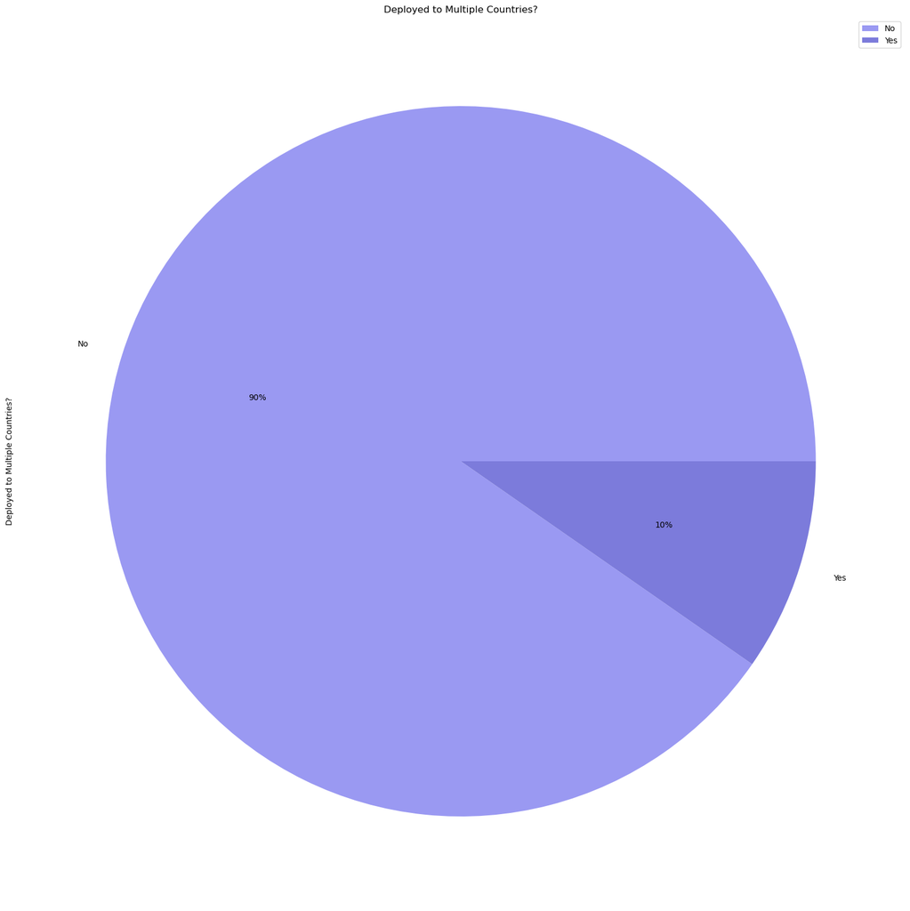

```python
Male_dataframe['Deployed to Multiple Countries?'].value_counts().plot(kind='pie',figsize=(20,20),title='Deployed to Multiple Countries?',legend=True,autopct='%1.0f%%',colors=Mcolors)
```

## Women

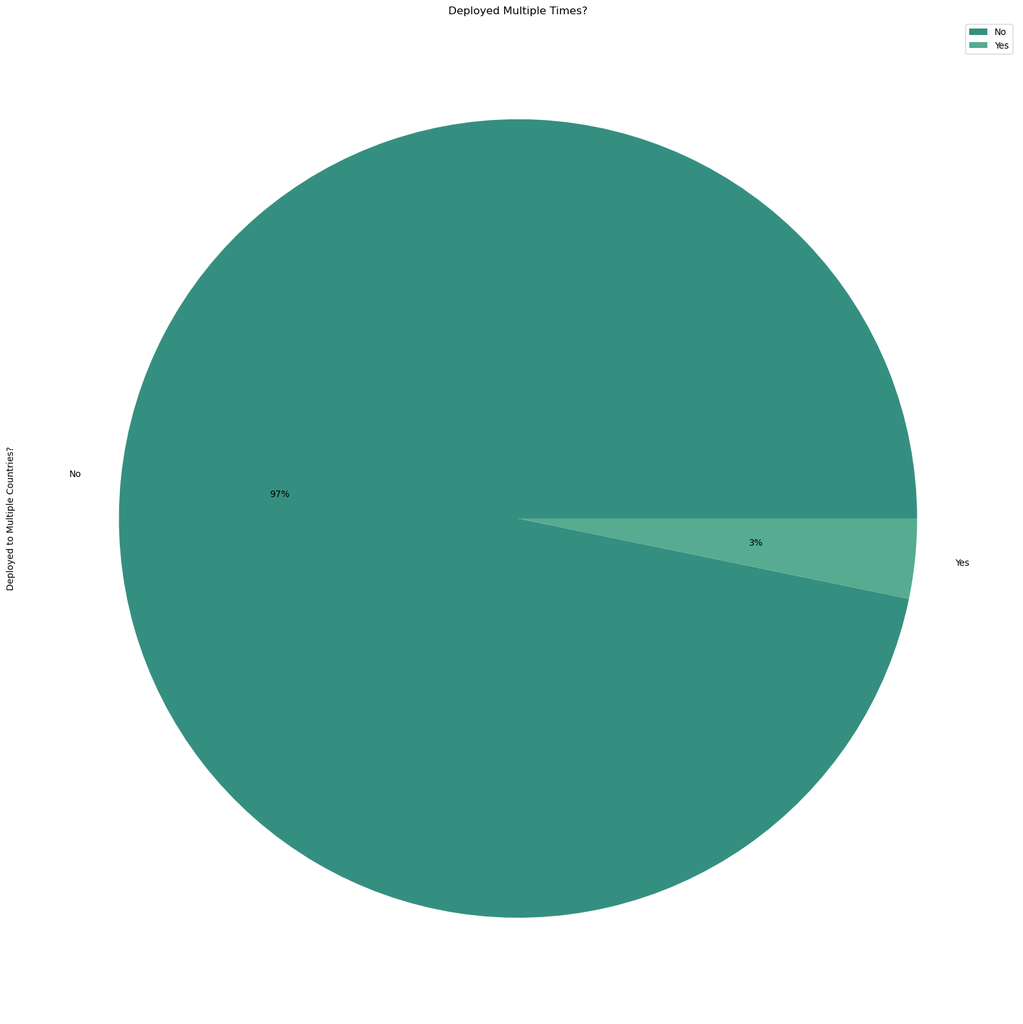

```python
Female_dataframe['Deployed to Multiple Countries?'].value_counts().plot(kind='pie',figsize=(20,20),title='Deployed Multiple Times?',legend=True,autopct='%1.0f%%',colors=colors)
```

Let's break this down, shall we?

32% of Male Agents were deployed multiple times, compared to 6% of female agents. That's 2 female agents to 10 male.

10% were deployed to multiple locations, compared to 3% of women. That's one female agent to three male.

The S.O.E. then was far more likely to redeploy men, and to deploy them in mutliple countries. In fact, some male agents even underwent plastic surgery to change their appearance if they were too well known to be redeployed.**4** Here, gender heavily impacts how men and women experienced their spywork, and the forms it took.

## Percentage of Deployment by Age Range

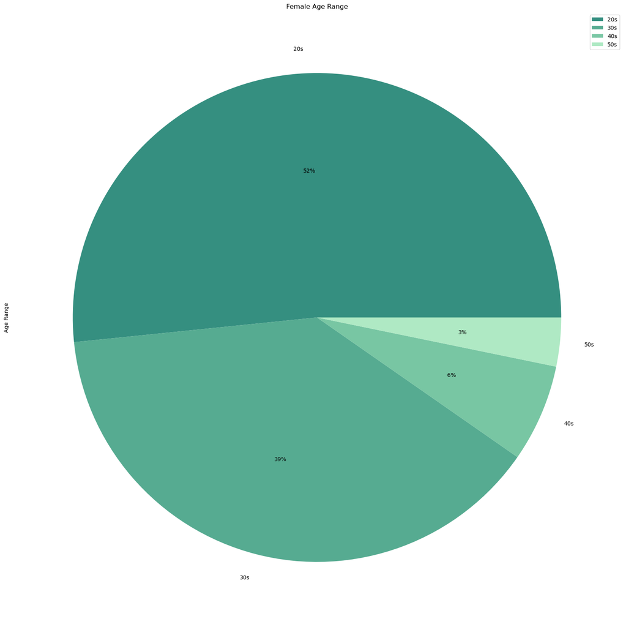

```python
Female_dataframe['Age Range'].value_counts().plot(kind='pie',figsize=(20,20),title='Female Age Range',legend=True,autopct='%1.0f%%',colors=colors)
```

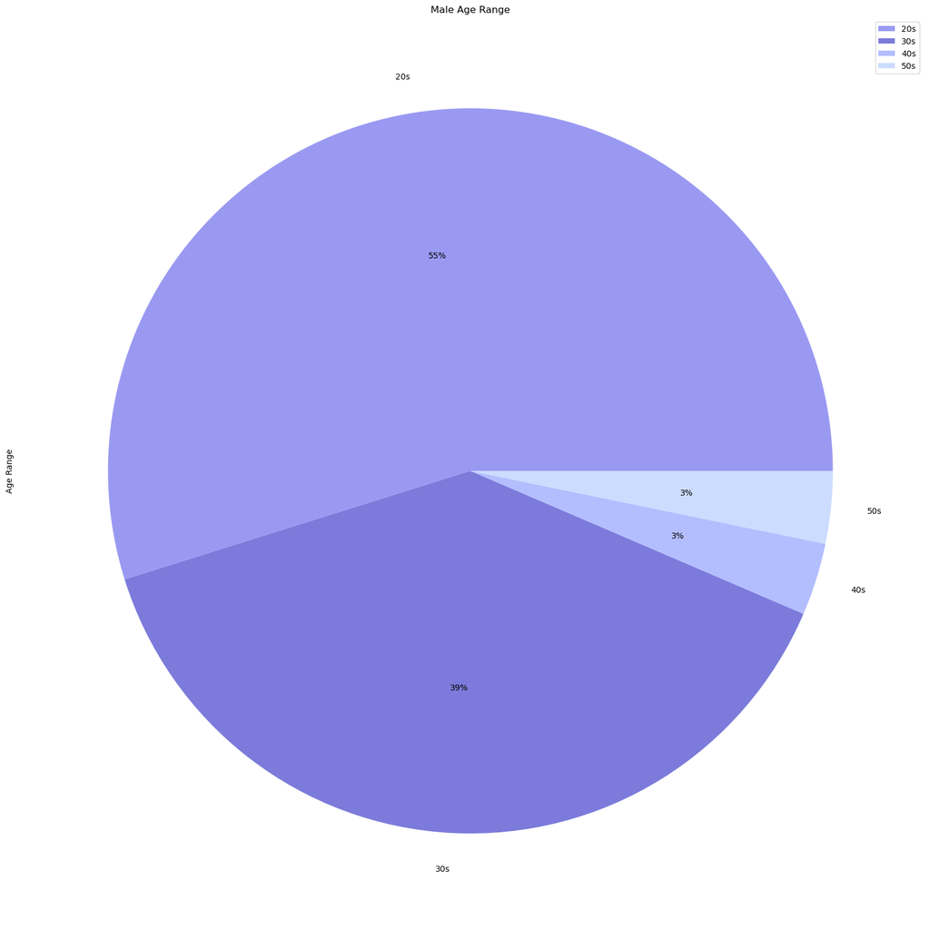

```python
Male_dataframe['Age Range'].value_counts().plot(kind='pie',figsize=(20,20),title='Male Age Range',legend=True,autopct='%1.0f%%',colors=Mcolors)
```

Over half of the women deployed were in their 20s. What does this tell us about how gender impacted agent's lives? To begin, female agents age had to hit a sort of sweet-spot, in a sense. Those bet fit to become S.O.E. agents did not have dependents, nor were they supposed to be accepted for compassionate reasons, such as joining the war because a loved one was killed. For women, in this sense, they aimed to recruit younger women who had yet to start families, but not too young. This can be seen across many countries and their thoughts on utilizing women for war, such as in Canada and their wartime production, choosing first single women to employ, then married women without children, until finally deploying married women with children. Despite this widespread belief, this did not stop married women, mothers, or older women from being deployed.

Male agents who survived their experiences, quite similarly to women, were majorily in their 20s when they were deployed, with young men with no dependents the ideal agent. The youngest of these male agents, grouped into the 20s, is Claude Georges Arnault, who was just 19 when he was deployed into France, and the youngest female agent was Sonya Butt, age 20. Their youth would have aided them in their work, both in their levels of energy and in being able to fit into French society without raising suspicion. Along with being young, looking young was also valued by the S.O.E., seen in the unique case of Phylis Latour. Latour's cover story, despite the fact she was 23, was that she was a young teenage girl the age of 14.**5** Her youth was an asset to her, but this youthfulness was also originally disliked by the S.O.E., who were wanted young but mature agents.

# Job Title

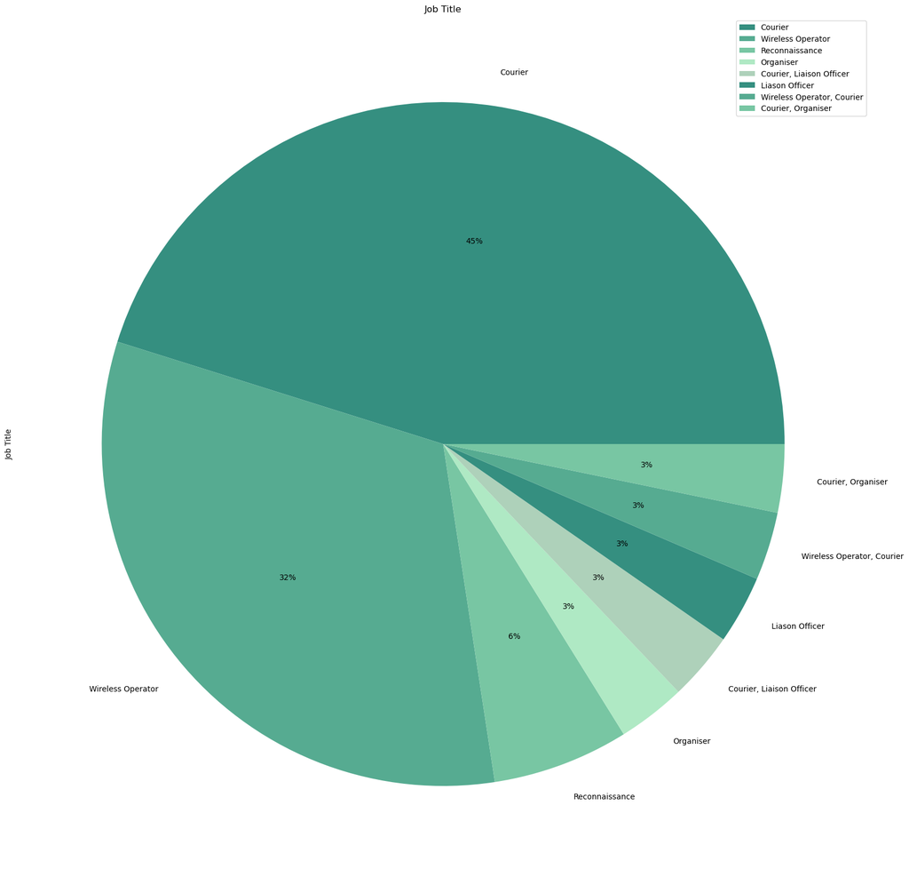

```python
Female_dataframe['Job Title'].value_counts().plot(kind='pie',figsize=(20,20),title='Job Title',legend=True,autopct='%1.0f%%',colors=colors)
```

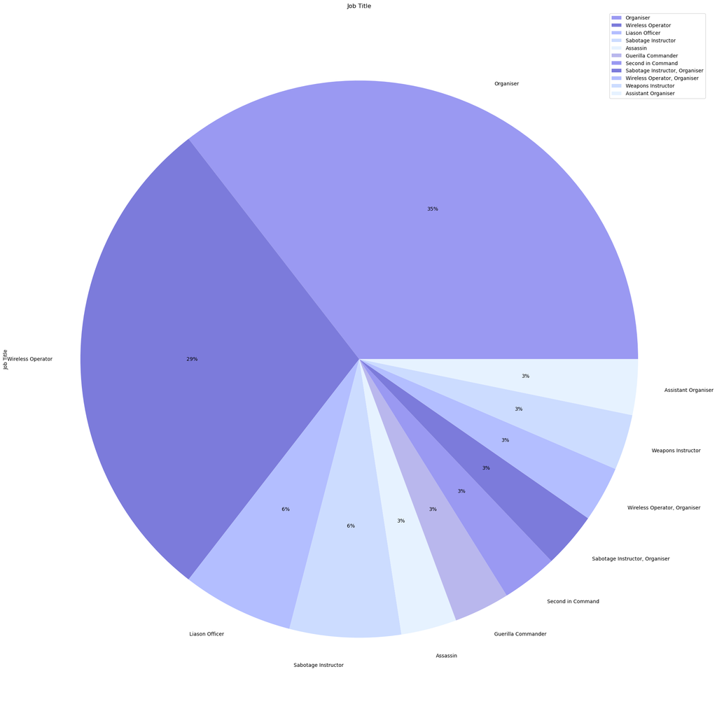

```python
Male_dataframe['Job Title'].value_counts().plot(kind='pie',figsize=(25,25),title='Job Title',legend=True,autopct='%1.0f%%',colors=Mcolors)
```

In the field, female S.O.E. agents were majorly couriers and wireless operators, which relates directly to their gender, because these positions were seen as more fit for women, with wireless operators hidden away and protected for their value, never seeing combat, and couriers used as they could move across France without raising suspicion. Some female agents would even hide the messages they carried in ribbons in their hair. Once deployed, they could take on multiple roles as their circuits saw fit, but what's worth noting is the 6% of female operatives who took on the role of 'Organiser', meaning they ran their own circuits, the largest and most daunting job an S.O.E. officer could take on.

Pearl Witherington Cornioley and Virginia Hall make up this 6%. There is so much I could say about these two women, but I will keep it brief:

For Pearl Witherington Cornioley, after her organiser Maurice Southgate was captured, she transitioned from a courier to an organiser, creating her own circuit.**6** She was an incredibly successful organiser, controlling 2,000 Maquis and collaborating with other circuits to cause 800 interruptions of railway lines in June 1944.**7** Cornioley turned down a civil MBE following her work, as she believed there was nothing civil about her work, and fought for a military MBE, which was yet another battle she won, as in 1946, she and other female S.O.E. agents were given military MBE's.**8**

Virginia Hall, as one of the first women deployed in France, organised her own circuit and was incredibly skilled in the field, evading capture for a total 15 months, the most of any female agent. She is the only female agent explicitly given the role of organiser. Her work organizing the Mauzac freed numerous S.O.E. agents was considered one of the most useful of the S.O.E.'s operations, but the resulting crack down by the Nazi regime following the prisonbreak would result in Hall's evacuation from France, and the refusal of the S.O.E. to send her back.**9** Determined, Hall joined the Office of Strategic Services (OSS), the American precursor to the C.I.A., and she was sent back into the field for another 6 months without capture, which cannot be counted within this dataset, as she no longer worked for the S.O.E.**10**

Of the male agents deployed with them, however, they were far more likely to start as organisers from the very beginning, or to take on more unique roles. Percy Mayer, for instance, was sent into the field as an assassin, explicitly tasked with killing the head of the Gestapo in Marseille, though it never came to fruition. Men also were tasked with being sabotage and weapons instructors, roles that female agents also filled, but as agents like Anne-Marie Walters recount, men could find it "distasteful" learning such tasks from women. **11**

Overall, gender perhaps played the biggest part in shaping agents experiences through was jobs they were given and what was expected of them in the field. Men were expected to be organisers, leading operations, handling weapons, and doing far more dangerous tasks while women, despite already being spies behind enemy lines, were kept hidden as radio operators, or used as couriers to travel to places where men would've raised suspicion.

# Location of Birth

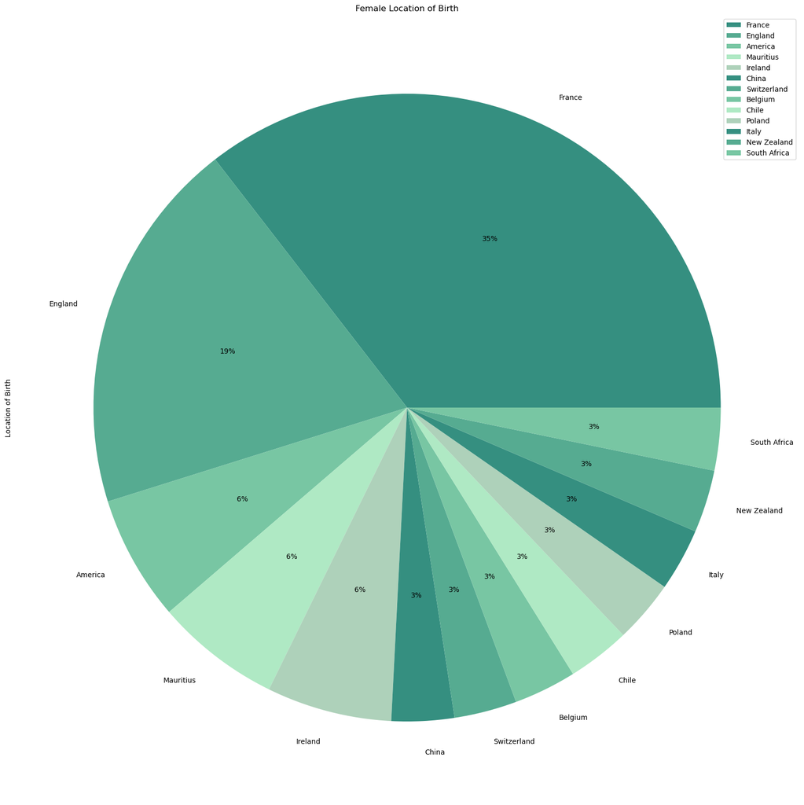

```python
Female_dataframe['Location of Birth'].value_counts().plot(kind='pie',figsize=(20,20),title='Female Location of Birth',legend=True,autopct='%1.0f%%',colors=colors)
```

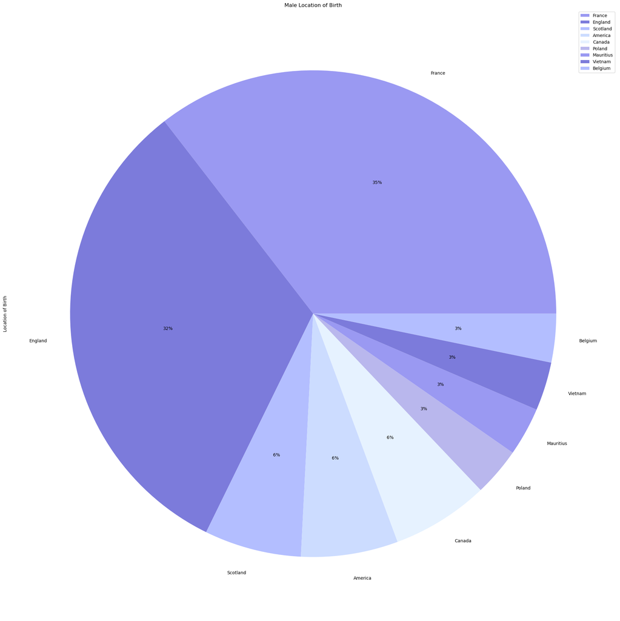

```python
Male_dataframe['Location of Birth'].value_counts().plot(kind='pie',figsize=(25,25),title='Male Location of Birth',legend=True,autopct='%1.0f%%',colors=Mcolors)
```

As expected, to send agents into France, there would be a preference for French agents, making up 35% of both female and male agents Birth locations.

Following is England, though it was far more likely for male agents featured in this dataset to be from Enland than female agents, from 32% to 19%. England, as the homebase of the S.O.E., would be a prime area to recruit agents from, but it's worth noting as well during this time that many agents were born in parts of the British empire, such as Scotland, Canada, Mauritius, South Africa, etc.

# Injury/Other and Capture

Finally, how did gender impact injury or capture of agents?

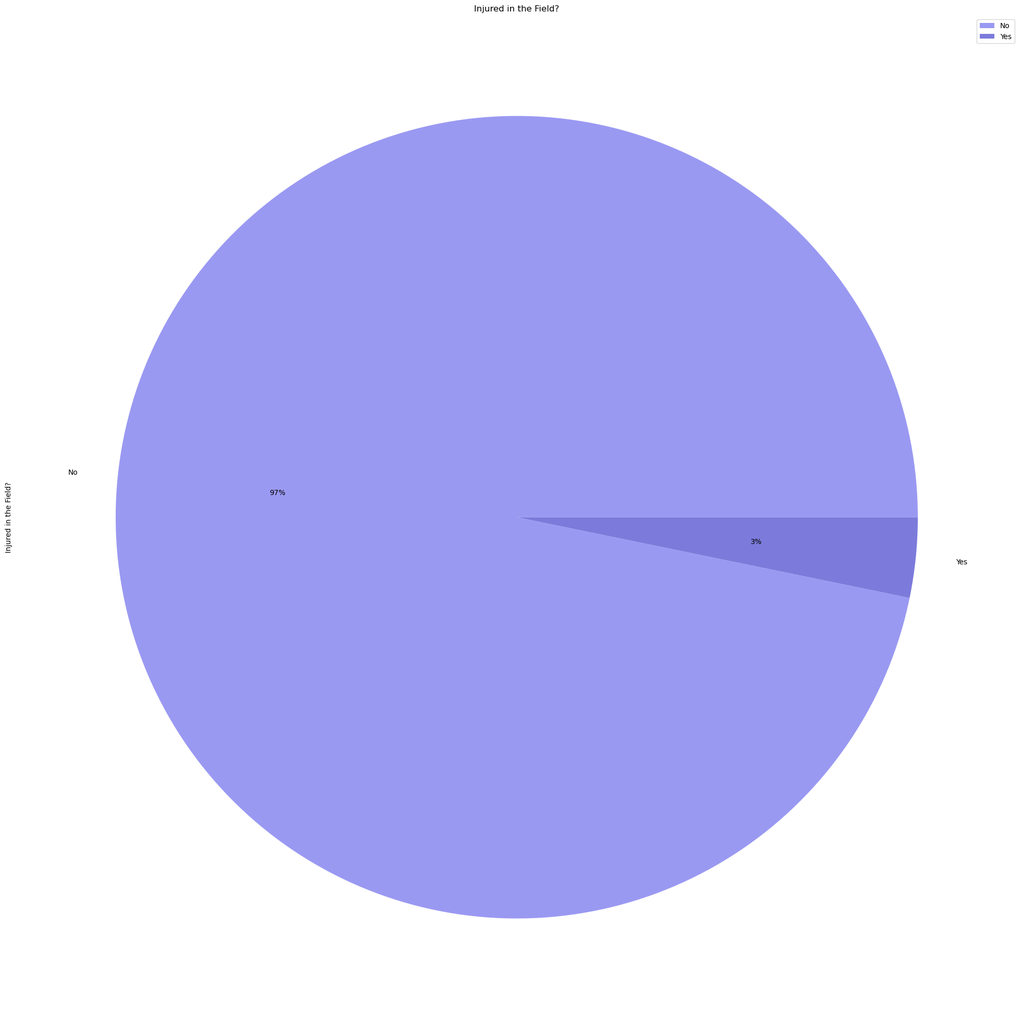

```python
Male_dataframe['Injured in the Field?'].value_counts().plot(kind='pie',figsize=(25,25),title='Injured in the Field?',legend=True,autopct='%1.0f%%',colors=Mcolors)
```

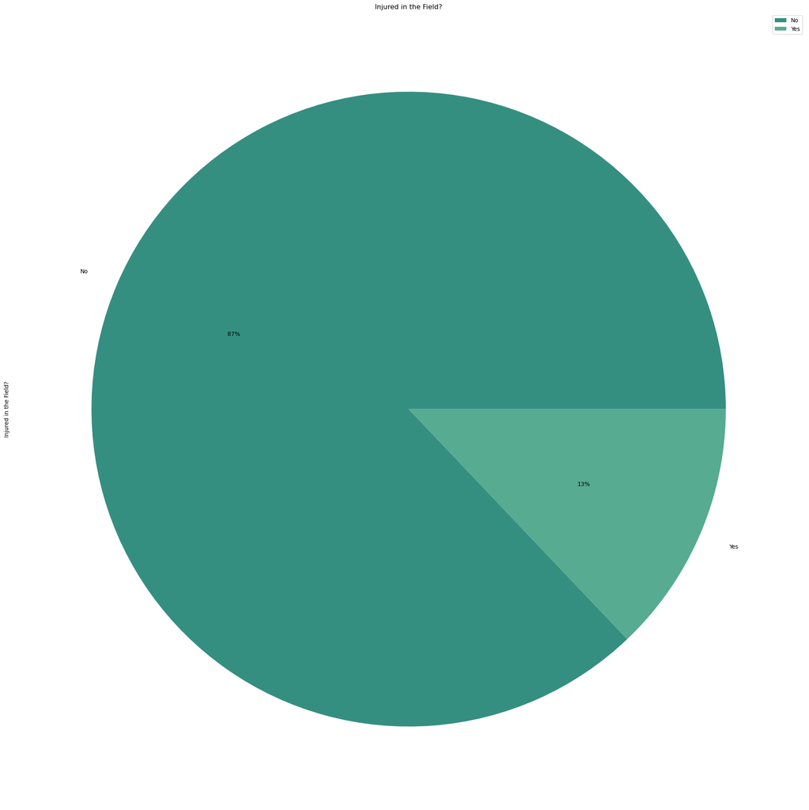

```python
Female_dataframe['Injured in the Field?'].value_counts().plot(kind='pie',figsize=(25,25),title='Injured in the Field?',legend=True,autopct='%1.0f%%',colors=colors)
```

Injury in the field was a potential concern for agents, whether injuring themselves upon landing when parachuted into countries, caught in the line of fire, or just natural mishaps. André Bouchardon, the only male agent injured in this dataset, was said to have been "severely wounded" while he was a wireless operator, forcing him back to England.**12** Yvonne Cormeau, the female agent injured, was shot in the leg while fleeing from the Germans, though she was not removed from the field as a result.**13**

Note, however, that this category is "Injury/Other". This is because certain agents experienced things in the field that, while not quite an injury, deserve discussion. Muriel Byck and Madeline Lavigne both died in the field, however, enemy fire is not what took them out, but natural causes. Byck passed of menegitis in the field, while Lavigne passed of an embolism.**14** Another inclusion in this category of "Other" is Mary Herbert, who fell pregnant in the field by her organiser, Claude de Baissac.**15** While Herbert was able to continue her work for a brief time, eventually she was removed from the field as she neared labour, and De Baissac was forced back to England.**16** Herbert would give birth in the field in a safehouse, which a short time after was raided by Nazi officers, who arrested Herbert, forcing her to give up her child.**17** Herbert, however, was able to convince the officers she was not an agent and simply a new mother, and was released and able to take back her child, after which she disappeared.**18** Following the end of the war, de Baissac would return to France in search of her, and found her living in the French countryside with their child.**19**

Did gender impact injuries, or other bodily changes in the field? As mentioned above, gender impacted what jobs agents were given, and in turn, the types of danger they were in, which would in turn impact how agents were injured. In this sample of agents, both Cormeau and Bouchardon were wireless operators, and were both wounded despite the 'safety' of this task compared to being an agent in the field. While this is not to say it was more likely for wireless operators to be injured than those in the field, what it does say is that wireless operators were more likely to survive their injuries than those in the field, who were in far more danger, and were far more likely to die.

As for the two women who passed of natural causes, these cannot be counted towards either gender or work in the field, as it was truly just biological happenstance, though it could be argued that Byck might have gotten meningitis from working with different agents in potentially unclean work environments, which was very likely considering the secretive nature of their work.

Herbert is perhaps the most obvious form of gendered bodily change, with pregnancy a uniquely female experience. For men in the field, falling pregnant was not a concern, but for female agents, it was a very real issue if they were sexually active or assaulted. Pregnancy was the end of an agent's ability to be an S.O.E. agent, but it was also a threat to their health, considering it was dangerous for S.O.E. agents to be brought to German run hospitals, and many agents were stationed far in the French countryside. Herbert, while a unique case, shows the unique concerns women faced in the field.

Beyond injury, what about capture?

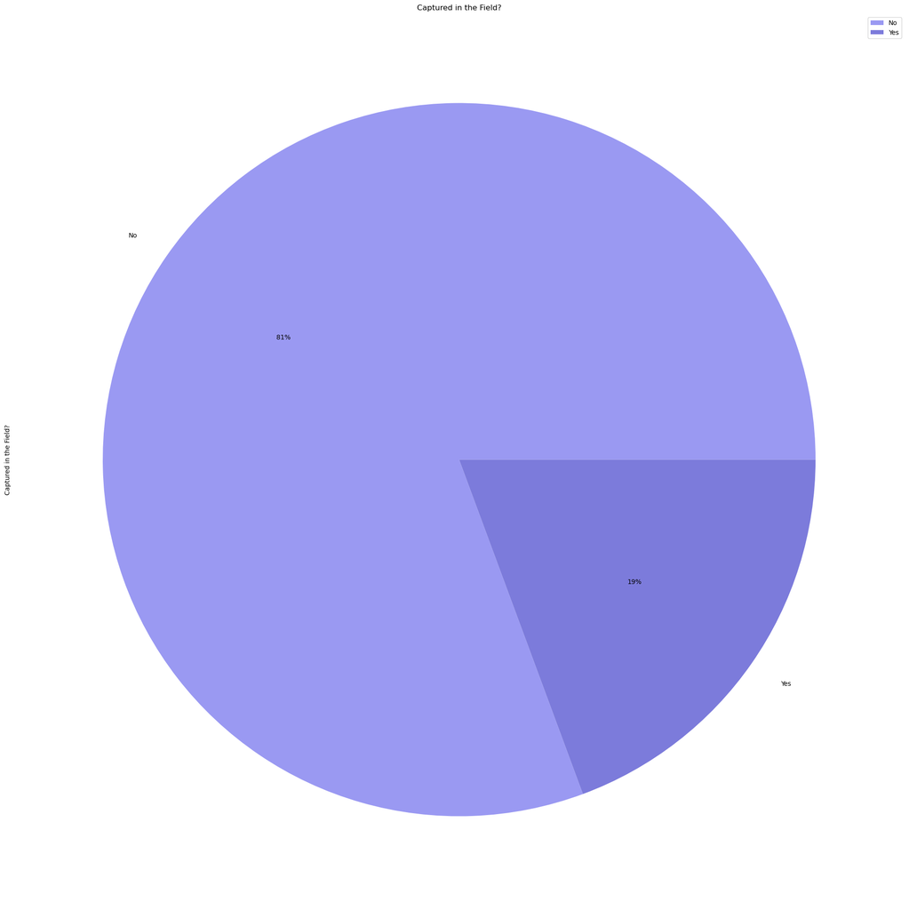

```python
Male_dataframe['Captured in the Field?'].value_counts().plot(kind='pie',figsize=(25,25),title='Captured in the Field?',legend=True,autopct='%1.0f%%',colors=Mcolors)
```

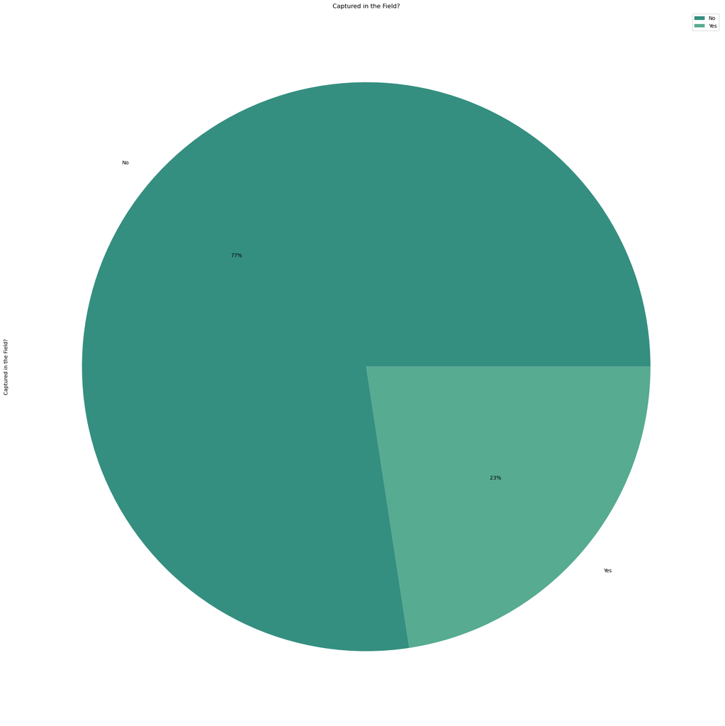

```python
Female_dataframe['Captured in the Field?'].value_counts().plot(kind='pie',figsize=(25,25),title='Captured in the Field?',legend=True,autopct='%1.0f%%',colors=colors)
```

As these two datasets show, women were slightly more likely to be captured, with 19% of male agents captured, and 23% female.

To begin by clarifying terminology, capture means being arrested by the Nazi forces and held, whether in detention, French prison, or concentration camps. Of the 7 female agents captured, Alix D'Unionville, Mary Katherine Herbert, and Blanche Charlet were not sent to concentration camps. Alix D'Unionville feigned mental illness to stay within France and the hospital system, and when she was to be sent to Germany, she escaped from her train.**20** Blanche Charlet was kept in prison in France where she escaped from before returning briefly to work in France until she could be safely returned to England, and Mary Katherine Herbert was arrested briefly, but managed to convince her captors that she was not an agent, and was set free.**21** Of those sent to concentration camps, only Eileen Nearne escaped. The other women were released and returned to England at the end of the war.

Of the 6 male agents captured, 3 were not sent to concentration camps: Pierre Boutoule, Arthur Staggs, and Sydney Hudson. Hudson and Boutole were both kept in French prisons, and only Hudson managed to escape. Staggs was detained, however, similarly to Herbert, a lack of evidence allowed him after months of detention to be freed.**22** The 3 men who were sent to concentration camps were Roger Cotton-Burnett, Francis Cammaerts and Maurice Southgate, of whom Cammaerts' freedom was negotiated by Krystyna Skarbek. **23**

So what does this tell us? Often, it was not gender specifically that caused agents to be captured, but more often factors like their role in the field, with 4 being wireless operators and 4 being couriers, which would involve directly having contraband on your person in the form of wireless sets and coded messages. As well, wireless operators signals could give them away, making them easier to track. Similarly, many of these agents were in the field for over 12 months, meaning their longevity also would have impacted their capture, as the longer they were in the field, the more chances there were for their capture. What's also worth exploring is that these are the agents that SURVIVED capture, which also is where other factors can come into play.

The actions of some agents saved them from execution, such as Alix D'Unionville, who was able to feign illness to escape, or Staggs and Hebert, who were both able to use their training and wit to convince their captors that they were innocent, or Maurice Southgate, who was able to hide the day of liberation to survive the final wave of liquidation of Buchenwald.**24** While somewhat debated, it's claimed that Eileen Nearne escaped execution due to the misunderstanding that she was Winston Churchill's niece, though this did not stop her from torture and punishment with the concetration camp.**25**

Surviving capture was not as common for S.O.E. agents, and the reasons for their survival were truly varied. For more information about agents who were killed in action, check out the "Death" Section of this website.

# Conclusion: In Their Own Words

So, from the data gathered through this project, and now with the addition of their own words, what have we learned about the gendered experience of agents?

Gendered effects began with deployment. With already low numbers, 45 female agents were deployed, of whom 31 survived, compared to hundreds of male agents, who (of those included in this dataset) were 8 times more like to be given a leadership position than female agents. Despite this, female agents preserved in leadership positions. Yvonne Cormeau, a wireless operator, also took on odd jobs for her circuit which saw her directly involved with the Maquis, claimed that the "SOE never gave women jobs higher than wireless operator. They thought no French person would obey instructions from a woman, but I found that I had no problems at all in that respect." **26** Virginia Hall, and Pearl Witherington Cornioley, also found they had no issue leading in the field, from Hall organizing jailbreaks to Witherington-Cornioley taking over as organiser when her circuits organiser was killed. Witherington-Cornioley especially felt strongly about her position as a militant leader, as when she was awarded a Civil MBE, she turned it down. “I wrote to say I was sorry, a civil decoration wasn’t fair. It was the first time they’d sent women to work in an occupied country, and if all they could do was to give me a civil decoration then I didn’t want it. Either they did things properly or not at all. I said that I hadn’t done anything remotely civil for England during the war.” **27** Eventually, she would be given her Military MBE, but she was one of 16 female S.O.E. agents given a civil MBE. No Male S.O.E. agent was given a civil MBE, because they were considered soldiers. To explore the masculine side of deployment, male deployment was also influenced by gender and ideas of masculinity, as mentioned above, men were given leadership positions, but also given positions that dealt with sabotage and weapons, with power and violence seen as masculine. Wireless Operators and Couriers, then, were seen as more feminine roles, with women far more able to roam freely than male agents due to their gender, considering the lack of men in France, and the abundance of women. Many agents explicitly recognize this, from Nancy Wake claiming that "Women could get by with a smile and do things that men couldn’t and no matter what you had hidden in your handbag or your bicycle bag", Phylis Latour saying that "women could blend into the fabric of society better and draw less suspicion" and that the enemy "were fixated on me being young and female, not thinking of anything more dangerous like the suspicious behaviour of a secret agent." **28** As well, with women often taking jobs as typists and secretaries, they were well equipt to become wireless transmitters through their ability to type.

Gender also affected how agents, S.O.E. staff, and resistors worked together, and the public view of agents. As Phylis Latour, a female S.O.E. agent, outlines, "Many men...simply did not believe that women should serve behind enemy lines. This was, as they saw it, not a place for the fairer sex, and they probably thought we weren’t capable of it anyway. I, for one, felt that judgement at various points in training or on the ground and wanted to prove them wrong." **29** Agents were often shocked to find that those being deployed into their care, or those receiving them, were women. As Pearl Witherington Cornioley recounts about receiving a male parachutist, "You should have seen his expression when [a male S.O.E. agent] saw me! At that moment I didn’t understand why. Later, when I was wondering why he had looked so surprised to see me there, the penny dropped—he must have been expecting a man, not a woman!" **30** Same goes for Anne-Marie Walters, who received male parachutists, and wrote down the conversation they had: “I must say we didn’t expect to find a woman on the field,” the [male S.O.E. agent] went on. “We were expecting machine gun bullets, and instead we find a woman asking us if we’re okay...” **31** Gendered relations can also been seen in the comraderie between male and female agents. Female agents could become objects of affection, with agents like Sonya Butt and Guy D'Artois getting married, or in Mary Herbert and Claude de Baissac's case, having a love affair in the field that ended with Herbert pregnant.

Beyond romantic love, familial love was also present, showing the differing views of female agents and male. Pearl Witherington Cornioley recounted that "The men called me “our mother” and they still do. At that time I wasn’t old enough to be their mother—I was 29, whereas most of them were about 20—but I was indeed older than them," while Benjamin Cowburn wrote in a report about Virginia Hall that “If you sit in [her] kitchen long enough you will see most people pass through with one sort of trouble or another which [she] promptly deals with,” acting as “mother figure”. **32**

While male agents too could take on paternal roles, such as Harry Verlander singing younger agents to sleep, it is worth noting the language used with female agents. **33** With female agents in the field, their relations to male agents were not the same sort of comraderie language used in the case of Verlander, who, when his singing resulted in some agents crying, commented "What’s a few sobs between friends?".**34** He conceptualizes this act as friendship and comraderie towards his rookies, while when female agents are concerned, they are not viewed in through masculine soldier comraderie, but in relation as women to men, who were seen and treated as mother figures, rather than just superiors. In a time where women were not often given leadership postions within the military, or outside, the only female figure of power men could relate them to is a mother, an inherently gendered way female agents were viewed in the field, and subsequently treated.

Views towards women were also reflected in views towards male agents and masculinity, with Harry Verlander explaining how one of his fellow agents was eager to get away from a signal officer “whom he found to be too effeminate for his liking”. **35** While misogyny saw heavy pressures on female agents, hegemonic masculinities also saw men turn against each other if they were not perceived as ‘masculine’ enough. Once deployed, these gendered expectations placed upon female agents sometimes changed. Phylis Latour had this experience with her organiser, who originally did not want female agents. However, "[Claude de Baissac] had also come to realise that women were useful. He was on the record as being ‘against the use of women as agents because their nerves are not usually strong enough for the job’, but had since seen that they were invaluable — men readily aroused suspicion and got arrested, whereas women did not." **36** This can also be seen in male agents, such as Francis Cammaerts and Sydney Hudson, both featured in this dataset, who both requested female agents to join their circuits, whether "for the reason that it was easier for them to get around", or that when accompanied by women, "nobody took any notice of us at all".**37** This building of trust towards female agents can be reflected in that the most female agents were deployed in 1944, as it took time for female agents to prove themselves adept in the field, alongside the growing need for agents following more and more arrests. Despite this, women still were seen as a last resort and their deployment was carefully constructed, as once in the field, women on average lasted 3 months less than the men included in this dataset, and male agents of this dataset were 5 times as likely to be redeployed, whereas female agents were barred from being sent back into the field.

Gender impacted S.O.E. agents in a myriad of ways from dictating what jobs they could take, their ability to be redeployed, how long they might spend in the field, and as these quotes above hope to show, their everyday lives in the field.

Through digital methods and quantitative analysis, I hope this work shows you the finer details of the intricacies for those involved in my dataset, but once again, that this dataset is just the beginning, It covers 62 agents out of hundreds, but it is a start to better understanding these agents experiences, and uncovering the hidden histories of the S.O.E. experience.

## Endnotes:

1.M. R. D. Foot, *SOE in France: An Account of the Work of the British Special Operations Executive in France 1940-1944*, (Oxford: Taylor and Francis, 2004): xxvi, 212. https://doi.org/10.4324/9780203496138.  
2.Kate Vigurs, *Mission France:The True History of the Women of SOE.* (Yale University Press, 2021): 79.  
3.Foot, *SOE in France*, 293; Lynette Beardwood, "Villameur, Lise Marie de Baissac [née Lise Marie de Boucherville Baissac] (1905–2004), special operations officer and member of the FANY." *Oxford Dictionary of National Biography.* 3 Jan. 2008; https://www.oxforddnb.com/view/10.1093/ref:odnb/9780198614128.001.0001/odnb-9780198614128-e-93513.  
4.See Bailey, Roderick. “Special Operations: A Hidden Chapter in the Histories of Facial Surgery and Human Enhancement.”*Medical Humanities* 46, no. 2 (2020): 115–23. https://doi.org/10.1136/medhum-2019-011792.

5.Pippa Latour, *The Last Secret Agent: The Extraordinary Story of a WW2 Spy, Told in Her Own Words.* (Monoray, 2024): 142.

6.Pearl Witherington Cornioley, *Codename Pauline.* (Chicago: Chicago Review Press, 2013): 47-48.

7.Foot, *SOE in France*, 47-48, 389.

8.Witherington Cornioley, *Codename Pauline,* 108-110.

9.Foot, *SOE in France*, 203-204; Sonia Purnell, *A Woman of No Importance: The Untold Story of the American Spy Who Helped Win World War II.* (New York: Viking, 2019): 261, 322-324.

10.Purnell, *A Woman of No Importance*, 328-331.

11.Anne-Marie Walters, *Moondrop to Gascony* (London: Pan Books, 1951): 76.

12."Bouchardon, Andre J." Traces of War, accessed March 28th, 2026. https://www.tracesofwar.com/persons/86766/Bouchardon-Andre-J.htm

13."Yvonne Cormeau", Eisenhower Foundation, accessed March 28th, 2026. https://eisenhowerfoundation.net/soldier/yvonne-cormeau

14.Foot, *SOE in France*, 383; Vigurs, *Mission France*, 173.

15.Juliette Pattinson, *Behind Enemy Lines: Gender, Passing and the Special Operations Executive in the Second World War.* (Manchester: Manchester University Press, 2007): 73 ; Vigurs, *Mission France*, 108.

16.Vigurs, *Mission France*, 62.

17.Vigurs, *Mission France*, 108-109.

18.Pattinson, *Behind Enemy Lines*, 156; Vigurs, *Mission France*, 108-109.

17.Vigurs, *Mission France*, 192 .

20.“Alix d’Unienville, SOE agent - obituary” The Telegraph, November 20, 2015. https://www.telegraph.co.uk/news/obituaries/12005980/Alix-dUnienville-SOE-agent-obituary.html;

21.Foot, *SOE in France*, 215; Vigurs, *Mission France*, 109 .

22.Foot, *SOE in France*, 265; Arthur Staggs, *A Veteran Interview with Arthur Staggs.* Legasee, accessed March 28, 2026. https://www.legasee.org.uk/veteran/arthur-staggs/

23.Foot, *SOE in France*, 412.

24.“Alix d’Unienville, SOE agent - obituary” The Telegraph; Laurence Wilkinson, "The Fiend Woman of Buchenwald", *The Sunday Express* (London, UK), April 22, 1945.

25.Foot, *SOE in France*, 430.

26.Pattinson, *Behind Enemy Lines*, 61.  
27.Witherington Cornioley, *Codename Pauline,* 108.

28.Pattinson, *Behind Enemy Lines*, 149; Latour, *The Last Secret Agent*, 23, 188.

29.Latour, *The Last Secret Agent*, 24.

30.Witherington Cornioley, *Codename Pauline,* 63.

31.Walters, *Moondrop to Gascony*, 179.

32.Purnell, *A Woman of No Importance:* 164; Witherington Cornioley, *Codename Pauline.*, 91.

33.Harry Verlander, *My War in SOE* (Bromley: Independent Books, 2010): 42-43.

34.Verlander, *My War in SOE*, 43.

35.Verlander, *My War in SOE*, 230.

36.Latour, *The Last Secret Agent*, 154.

37.Pattinson, *Behind Enemy Lines*, 139.

38.Latour, *The Last Secret Agent*, 23.  
39.Nancy Wake, *The White Mouse* (Melbourne: The MacMillan Company of Australia, 1987): 142.

40.Latour, *The Last Secret Agent*, 233.

41.Pattinson, *Behind Enemy Lines*, 144.

42.Pattinson, *Behind Enemy Lines*, 167.

## Bibliography

“Alix d’Unienville, SOE agent - obituary” The Telegraph. November 20, 2015. https://www.telegraph.co.uk/news/obituaries/12005980/Alix-dUnienville-SOE-agent-obituary.html

Beardwood, Lynette. "Villameur, Lise Marie de Baissac [née Lise Marie de Boucherville Baissac] (1905–2004), special operations officer and member of the FANY." *Oxford Dictionary of National Biography.* 3 Jan. 2008. https://www.oxforddnb.com/view/10.1093/ref:odnb/9780198614128.001.0001/odnb-9780198614128-e-93513.

"Bouchardon, Andre J." Traces of War. Accessed March 28th, 2026. https://www.tracesofwar.com/persons/86766/Bouchardon-Andre-J.htm

Foot, M. R. D. SOE in France: An Account of the Work of the British Special Operations Executive in France 1940-

```
1944. Oxford: Taylor and Francis, 2004. https://doi.org/10.4324/9780203496138.
```

Latour, Pippa. The Last Secret Agent: The Extraordinary Story of a WW2 Spy, Told in Her Own Words. Monoray, 2024.

Pattinson, Juliette. Behind Enemy Lines: Gender, Passing and the Special Operations Executive in the Second World War. Manchester: Manchester University Press, 2007.

Purnell, Sonia.*A Woman of No Importance: The Untold Story of the American Spy Who Helped Win World War II.* New York: Viking, 2019.

Staggs, Arthur. *A Veteran Interview with Arthur Staggs.* Legasee. Acccessed March 28, 2026. https://www.legasee.org.uk/veteran/arthur-staggs/

Verlander, Harry. *My War in SOE*. Bromley: Independent Books, 2010.

Vigurs, Kate. *Mission France:The True History of the Women of SOE.* Yale University Press, 2021.

Wake, Nancy. *The White Mouse*. Melbourne:The MacMillan Company of Australia, 1987.

Walters, Anne-Marie *Moondrop to Gascony*. London: Pan Books, 1951.

Wilkinson, Laurence. "The Fiend Woman of Buchenwald", *The Sunday Express* (London, UK), April 22, 1945.

Witherington Cornioley, Pearl. Codename Pauline. Chicago: Chicago Review Press, 2013.

"Yvonne Cormeau", Eisenhower Foundation. Accessed March 28th, 2026. https://eisenhowerfoundation.net/soldier/yvonne-cormeau